[figure not shown]

**International Journal of Radiation Biology**

**ISSN: (Print) (Online) Journal homepage: https://www.tandfonline.com/loi/irab20**

[figure not shown]

**Neurocognitive and radiological changes after**

**cranial radiation therapy in humans and rodents: a**

**systematic review**

**Whitney D. Perez & Carlos J. Perez-Torres**

**To cite this article:** Whitney D. Perez & Carlos J. Perez-Torres (2022): Neurocognitive and

radiological changes after cranial radiation therapy in humans and rodents: a systematic review,

International Journal of Radiation Biology, DOI: 10.1080/09553002.2022.2074167

**To link to this article:** https://doi.org/10.1080/09553002.2022.2074167

[figure not shown]

[figure not shown]

[figure not shown]

[figure not shown]

[figure not shown]

[figure not shown]

ORGINAL ARTICLE

Neurocognitive and radiological changes after cranial radiation therapy in

humans and rodents: a systematic review

Whitney D. Perez<sup>a</sup>and Carlos J. Perez-Torres<sup>a</sup><sup>,</sup><sup>b</sup><sup>,</sup><sup>c</sup><sup>,</sup><sup>d</sup>

aSchool of Health Sciences, Purdue University, West Lafayette, IN, USA; bPurdue University Center for Cancer Research, Purdue University,

West Lafayette, IN, USA; <sup>c</sup>Academy of Integrated Science, Virginia Polytechnic Institute and State University, Blacksburg, VA, USA; <sup>d</sup>School of

Neuroscience, Virginia Polytechnic Institute and State University, Blacksburg, VA, USA

ABSTRACT

Background: Radiation-induced brain injury is a common long-term side effect for brain cancer

survivors, leading to a reduced quality of life. Although there is growing research pertaining to

this topic, the relationship between cognitive and radiologically detected lesions of radiation-

induced brain injury in humans remains unclear. Furthermore, clinically translatable similarities

between rodent models and human findings are also undefined. The objective of this review is to

then identify the current evidence of radiation-induced brain injury in humans and to compare

these findings to current rodent models of radiation-induced brain injury.

Methods: This review includes an examination of the current literature on cognitive and radio-

logical characteristics of radiation-induced brain injury in humans and rodents. A thorough search

was conducted on PubMed, Web of Science, and Scopus to identify studies that performed cogni-

tive assessments and magnetic resonance imaging techniques on either humans or rodents after

cranial radiation therapy. A qualitative synthesis of the data is herein reported.

Results: A total of 153 studies pertaining to cognitively or radiologically detected radiation injury

of the brain are included in this systematic review; 106 studies provided data on humans while 47

studies provided data on rodents. Cognitive deficits in humans manifest across multiple domains

after brain irradiation. Radiological evidence in humans highlight various neuroimaging-detectable

changes post-irradiation. It is unclear, however, whether these findings reflect ground truth or

research interests. Additionally, rodent models do not comprehensively reproduce characteristics

of cognitive and radiological injury currently identified in humans.

Conclusion: This systematic review demonstrates that associations between and within cognitive

and radiological radiation-induced brain injuries often rely on the type of assessment. Well-

designed studies that evaluate the spectrum of potential injury are required for a precise under-

standing of not only the clinical significance of radiation-induced brain injury in humans, but also

how to replicate injury development in pre-clinical models.

ARTICLE HISTORY

Received 18 January 2022

Accepted 20 April 2022

KEYWORDS

Radiation-induced brain

injury; rodent models;

cognition; imaging

Introduction

Radiation therapy is a practical and critical tool to manage

intracranial tumors due to its ability to non-invasively treat

cases of metastatic or deeply seated brain tumors (Lee et al.

2012). As high-energy radiation particles are delivered to the

tumor site, a fraction of this energy will inevitably be depos-

ited within the healthy brain tissue along the radiation

beam’s path and immediately adjacent to the tumor. As a

consequence of normal tissue irradiation, many patients

undergoing cranial radiation therapy experience neurological

side effects. Indeed, long-term side effects of cranial irradi-

ation have been reported to occur in 50–90% of adult

patients (Greene-Schloesser and Robbins 2012) and up to

50% of pediatric patients (Ajithkumar et al. 2017). It has

been shown that these radiation-induced brain injuries

ultimately lead to a decrease in quality of life after cancer

therapy (Corn et al. 2008; Correa et al. 2012). The prognosis

and severity of these side effects, however, depends on the

time of clinical expression and are therefore generally cate-

gorized as acute, early-delayed, and late-delayed brain injury

(Greene-Schloesser and Robbins 2012). The acute and early-

delayed effects, which usually occurs from a few days up to

6 months after irradiation, are transient and typically self-

resolve. Late-delayed radiation effects, which usually occurs

from 6 months up to an indefinite number of years after

therapy, do not self-resolve. Due to increasing survival out-

comes for brain tumor patients (Siegel et al. 2018), and thus

a growing population of long-term survivors, this late-

delayed form of radiation induced-brain injury (RIBI) is the

primary

concern

in

terms

of

radiation-induced

neurotoxicity.

Depending in part on the radiotherapy treatment para-

digm, late-delayed RIBI can present as a focal or diffuse

CONTACT Carlos J. Perez-Torres

cjpereztorres@vt.edu

210 Drillfield Dr, Sandy Hall 302, Blacksburg, VA, 24060, USA

Supplemental data for this article can be accessed here

https://doi.org/10.1080/09553002.2022.2074167

pathology (Valk and Dillon 1991; Soussain et al. 2009).

Radiation necrosis presents as a focal lesion with increased

vascular permeability and edema on magnetic resonance

imaging (MRI; Vellayappan et al. 2018). The cognitive dys-

functions associated with radiation necrosis include seizures,

focal weakness, language impairment, and blurred vision

(Giglio and Gilbert 2003; Diaz and Choi 2014). Although

radiation necrosis maintains high clinical relevance within

late-delayed effects of RIBI, it is not the primary focus of

this review as its incidence is usually small (roughly 5%).

The more common form of RIBI presents as a diffuse lesion

characterized by a homogeneous enhancement throughout

the subcortical white matter without increased vascular per-

meability or edema (Zhong et al. 2015). The cognitive

impairments associated with this form of RIBI include, but

are not limited to, deficits in attention, memory, executive

functioning, language, and psychomotor skills (Sundgren

and Cao 2009; Cramer et al. 2019). Other diffuse radio-

logical abnormalities such as cerebral volume loss, cerebral

microbleeds, changes in white matter diffusion metrics, and

changes in the neurometabolic profile have also been sug-

gested to be associated with the aforementioned cognitive

impairments (Robbins et al. 2012; Haller et al. 2018; Kłos

et al. 2019).

The current scientific understanding behind the patho-

physiology of these late-delayed forms of RIBI is built upon

studies of pre-clinical animal models. Results of these

experimental models, typically of healthy rodents, have

revealed a multitude of dynamic processes within rodent

brains after the delivery of radiation. These include, but are

not limited to, the impairment of hippocampal neurogenesis

(Dietrich et al. 2008; Fike et al. 2009; Capilla-Gonzalez et al.

2016), loss of neuronal function (Greene-Schloesser et al.

2013; Burns et al. 2016; Wilke et al. 2018), depletion of

oligodendrocyte progenitor cells (Greene-Schloesser et al.

2013; Burns et al. 2016), chronic neuroinflammation (Lee

et al. 2012; Burns et al. 2016; Lumniczky et al. 2017), and

damage to microvascular endothelium (Kim et al. 2008;

Warrington et al. 2013). However, it remains unclear how

these biological mechanisms underlie the clinical and radio-

logical presentations of late-delayed RIBI.

While the field of RIBI research has provided a wealth of

literature on patient outcomes and animal modeling, it is

important to evaluate how these findings fit together to

form a complete understanding of RIBI development. The

objective of this systematic review of the literature is to first

establish an interdisciplinary understanding of the current

clinical evidence of RIBI, and then confirm rodent model

accuracy

with

respect

to

current

clinical

end

points.

Therefore, the three key questions we have set out to answer

in this systematic review are:

1.

What are the current cognitive and radiological assess-

ments used to evaluate late-delayed RIBI?

2.

What are the relationships between and within cognitive

and

radiological

findings

of

late-delayed

RIBI

in

humans?; and

3.

How well do rodent models of RIBI replicate to the

cognitive

and

radiological

evidence

observed

in humans?

Methods

Search strategy

This systematic review adheres to the guidelines described

in the Preferred Reporting Items for Systematic Reviews and

Meta-Analyses (PRISMA) Statement (Moher et al. 2009).

The initial pool of studies pertaining to clinically or radio-

logically detected radiation injury of the brain in humans or

rodents were first collected through PubMed, Web of

Science, and SCOPUS using the search string listed in S1

Appendix. The search criteria were further limited by lan-

guage (English), time of publication (January 1980 to

January 2022), and publication status (full text must be

available). Case reports, editorials without original data, and

review articles were further excluded from the pool of initial

studies. Additional studies were included into this pool by

manually hand-searching references of included studies.

Study selection

A preliminary screening of the titles and abstracts was per-

formed based on the following inclusion criteria: (1) patients

must be treated with cranial radiation therapy; (2) rodent

models must receive a clinically relevant dose of ionizing

radiation to a disease-free brain; (3) outcome is measured

by a neurocognitive or neuroimaging assessment after a

specified period of time post-irradiation: at least 1 month for

rodents and 6 months for patients; (4) neurocognitive assess-

ments must evaluate global cognitive functioning or one of

the following domains: complex attention, executive func-

tioning, learning and memory, perceptual-motor function,

and language; (5) neuroimaging techniques must attempt to

identify at least one of the following radiation-induced

changes: cerebral atrophy, cerebral microbleeds, radiation-

induced leukoencephalopathy, changes in diffusion metrics,

and changes in metabolic profile. Respectively, these criteria

function to (1) establish patient data as the ground truth;

(2) verify deficits or lesions within rodent brains are exclu-

sively due to a radiation-induced normal tissue injury; (3)

ensure that the deficits or lesions measured are indeed late-

delayed effects and not acute effects of RIBI; (4) limit neuro-

cognitive outcomes to the domains in which impairments

are most commonly reported; (5) limit neuroimaging out-

comes to those previously reported to be associated with

neurocognitive impairment.

This limitation in neurocognitive and neuroimaging out-

comes was performed due to the wide range of possible

albeit infrequent side effects that could potentially occur

after radiation treatment. Neurocognitive assessments there-

fore focused on changes in the domains of language, execu-

tive function, learning and memory, complex attention,

perceptual-motor function, and general cognitive ability

according to previously reported guidelines (Sachdev et al.

2

2014; Janss et al. 2019). Furthermore, neuroimaging out-

comes are focused on those that have been shown to be

related to neurocognitive impairment, such as cerebral atro-

phy, cerebral microbleeds, radiation-induced leukoencephal-

opathy,

changes

in

diffusion

metrics,

and

changes

in

metabolic profile (Greene-Schloesser et al. 2012; Robbins

et al. 2012; Lupo and Nelson 2014). All evidence and defini-

tions of neurocognitive or radiological RIBI have been left

to the interpretation of the original authors.

Accepted studies based on this title and abstract screen-

ing were retrieved and saved to Zotero, our reference man-

agement database of choice. The full text of these studies

was then read to ensure quality of study methodology and

to confirm adherence to inclusion criteria.

Data extraction and analysis

Data were extracted from the studies that fulfilled the inclu-

sion and exclusion criteria. Details of study characteristics

were extracted, which included species, age, sex, sample size,

health status, irradiated volume, total dose, and dose per

fraction. Details of the relevant findings were extracted,

which included outcome measurement techniques, time of

outcome detection, and classification of outcome. For stud-

ies that contain groups with an experimental treatment arm,

only the group that has received solely radiation is consid-

ered for this review. Some studies may set forth the object-

ive of measuring both cognitive and radiological RIBI,

however fail to find evidence of either one or the other;

only the successfully detected form of RIBI will be incorpo-

rated as evidence in this review. Studies that do not provide

the techniques for cognitive or radiological RIBI assessment

will not be considered in our results. These collected data

were then organized and combined according to the authors’

categorization of evidence (cognitive or radiological RIBI,

rodent or human) in order to visualize their relationships

and diversity (Lex et al. 2014).

Results

Description of search results

The literature search identified a total of 2647 studies. After

the removal of duplicates, 1722 studies remained. Abstract

screening based on the inclusion criteria excluded 1562

studies, leaving a remaining total of 158 studies to undergo

full-text assessment. Five studies were excluded due to either

insufficient evidence of RIBI or omission of RIBI assessment

protocols, leaving a final group of 153 studies included in

this systematic review. A summary of this systematic search

of the literature, as well as the enumeration of included

studies, is provided in Figure 1. The comprehensive collec-

tion of details extracted from these studies, such as patient

demographics and treatment protocols, can be found in S1

Table (for human studies) and S2 Table (for rodent studies).

It is unclear whether the various relationships between

domains of cognitive impairment in human studies

reflect ground truth or research interests

We found a total of 49 studies that sought to investigate

cognitive RIBI within a human cohort. The following trends

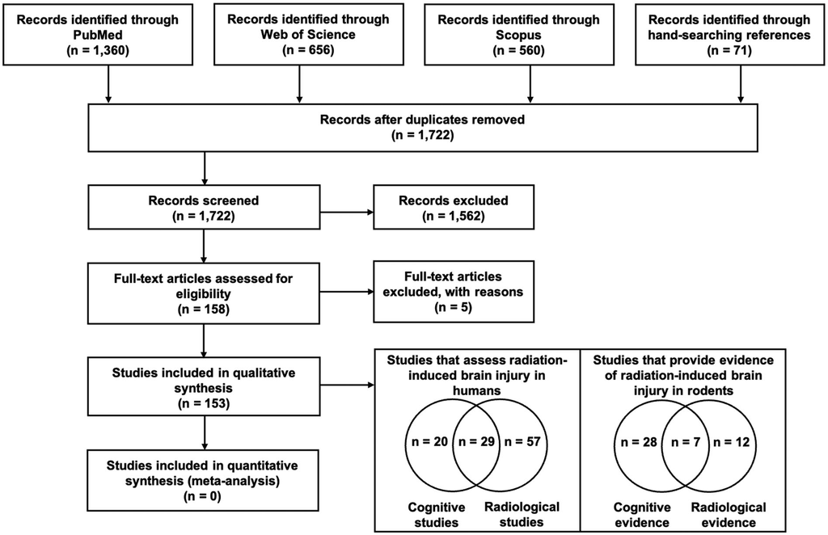

Figure 1. PRISMA flowchart for the identification and selection of studies.

3

were found in patients receiving cranial radiation therapy:

(1) impaired cognitive functioning occurs in the domains of

complex attention (Anderson et al. 1997; Schatz et al. 2000;

Mulhern et al. 2001; Armstrong et al. 2002; Reddick et al.

2003; Schatz et al. 2004; Mulhern et al. 2004; Moretti et al.

2005; Douw et al. 2009; Correa et al. 2012; Krull et al. 2013;

Schuitema et al. 2013; Butler et al. 2013; Reddick et al. 2014;

Edelmann et al. 2014; Schuitema et al. 2015; Chapman et al.

2016; Sim�o et al. 2016; Roddy et al. 2016; Follin et al. 2016;

Rashid et al. 2017; Bompaire et al. 2018), learning and mem-

ory (Mulhern et al. 1992; Mulhern et al. 2001; Armstrong

et al. 2002; Reddick et al. 2003; Chang et al. 2009; Chapman

et al. 2012; Correa et al. 2012; Krull et al. 2013; Riggs et al.

2014; Edelmann et al. 2014; Chapman et al. 2016; Sim�o

et al. 2016; Armstrong et al. 2016; Roddy et al. 2016; Follin

et al. 2016; Bompaire et al. 2018; Tringale et al. 2019; Brown

et al. 2020; Morrison et al. 2021), executive function

(Anderson et al. 1997; Schatz et al. 2000; Douw et al. 2009;

Correa et al. 2012; Krull et al. 2013; Schuitema et al. 2013;

Schuitema et al. 2013; Edelmann et al. 2014; Sim�o et al.

2016; Roddy et al. 2016; Follin et al. 2016; Rashid et al.

2017; Bompaire et al. 2018), perceptual-motor function

(Douw et al. 2009; Correa et al. 2012; Roddy et al. 2016;

Follin et al. 2016; Rashid et al. 2017; Redmond et al. 2018),

or language (MacLean et al. 1995; Chapman et al. 2012;

Sim�o et al. 2016; Follin et al. 2016; Tibbs et al. 2020); (2)

reduced aptitude occurs for general cognitive abilities such

as academic achievement, intellectual ability, and neurocog-

nitive functioning (Twaddle et al. 1983; Mulhern et al. 1992;

Radcliffe et al. 1994; Anderson et al. 1997; Schatz et al.

2000; Davidson et al. 2000; Mulhern et al. 2001; Reddick

et al. 2003; Mulhern et al. 2004; Moretti et al. 2005; Omuro

et al. 2005; Khong et al. 2006; Aoyama et al. 2007; Corn

et al. 2008; Tang et al. 2012; Krull et al. 2013; Schuitema

et al. 2013; Butler et al. 2013; Reddick et al. 2014; Edelmann

et al. 2014; Merchant et al. 2014; King et al. 2015; Schuitema

et al. 2015; Sim�o et al. 2016; Bompaire et al. 2018; Roth

et al. 2020; Alirezaei et al. 2021; Lin et al. 2021); and 3) cog-

nitive impairment does not occur in isolation, but rather

spans across multiple cognitive domains.

Within this pool of 49 studies, there were 120 cumulative

attempts to measure cognitive domain deficits after cranial

radiotherapy. Only 94 of these 120 efforts were successful;

the majority of viable evidence lies within the domains of

complex attention, learning and memory, and general cogni-

tive ability, while the minority lies within executive function,

language,

and

perceptual-motor

function

(Figure

2(a)).

Interestingly, some studies that attempt to comprehensively

assess multiple cognitive domains detected little to no forms

of cognitive impairment from their battery of assessments

(Waber et al. 2004; Chapman et al. 2016; Agbahiwe et al.

2017; Bian et al. 2019; Phillips et al. 2020). Other compre-

hensive studies had more success in measuring cognitive

impairments and were able to detect deficits using at least

half of their battery of assessments (Anderson et al. 1997;

Douw et al. 2009; Sim�o et al. 2016). Pooling together these

94 cases of successfully detected deficits, about 90% of the

current viable evidence of cognitive impairment in human

studies are composed of changes in general cognitive ability,

complex attention, learning and memory, or executive func-

tion with little consideration for the assessment of language

and perceptual-motor function (Figure 2(b)). Furthermore,

it can be observed that these 94 cases of cognitive deficits

do not occur in isolation, but rather encompasses multiple

domains (Figure 2(c)). Studies that show cognitive deficits

occurring in a single domain did not attempt to measure

changes in any other cognitive domains. This is relevant for

all isolated cases of general cognitive ability but excludes

one case of memory and learning and one case of com-

plex attention.

While there is a multitude of evidence for the impair-

ment of cognitive domains, these results differ due to their

heterogeneity of assessments (Figure 3). In our dataset, for

example, we find that 24% of all human cognitive impair-

ments are related to complex attention, which are measured

by 9 different types of assessments. Even if these deficits in

cognition are summarized and categorized into domains, the

type of assessment used to detect injury only provides a

fraction of the overall answer. For instance, Correa et al.

uses the Digit Span test to measure selective attention while

processing speed. These measurements of selective attention

and processing speed both fall under the category of com-

plex attention, but they describe different aspects of the

attention domain. Although we can picture general relation-

ships about the types of cognitive RIBI cases and their inter-

connections,

we

cannot

be

sure

whether

these

trends

represent the inherent characteristics of RIBI or are rather a

reflection of the field’s vested interest in particular RIBI

subcategories.

Trends can be easily deduced from human studies of

MRI-detectable radiation injuries due to the generality

of neuroimaging techniques

We found a total of 86 studies that sought to investigate

radiological RIBI within a single human cohort. The follow-

ing trends were found in patients receiving cranial radiation

therapy: (1) changes in diffusion present as decreases in

fractional anisotropy and increases in mean diffusivity, lon-

gitudinal diffusivity, or perpendicular diffusivity within glo-

bal white matter (WM) or WM regions such as the fornix,

cingulum bundle, corpus callosum, uncinate fasciculus, ven-

tral cingulum, genu, and splenium (Khong et al. 2006;

Nagesh et al. 2008; Haris et al. 2008; Rueckriegel et al. 2010;

Chapman et al. 2012; Xiong et al. 2013; Schuitema et al.

2013; Edelmann et al. 2014; Hope et al. 2015; King et al.

2015; Sim�o et al. 2016; Connor et al. 2016; Duan et al. 2016;

Connor et al. 2017; Leng et al. 2017; Makola et al. 2017;

Redmond et al. 2018; Bompaire et al. 2018; Follin et al.

2019; Morrison et al. 2019; Bian et al. 2019); (2) the major-

ity of cerebral atrophy studies measure the change in WM

volumes, which are shown to decrease post-irradiation

(Usenius et al. 1995; Reddick et al. 1998; Davidson et al.

2000; Mulhern et al. 2001; Armstrong et al. 2002; Reddick

et al. 2003; Mulhern et al. 2004; Reddick et al. 2005; Faraci

4

et al. 2011; Riggs et al. 2014; Reddick et al. 2014; Edelmann

et al. 2014; Follin et al. 2016; Tibbs et al. 2020; Lin et al.

2021); (3) the total number of cerebral microbleeds detected

within a patient increases with time after cranial irradiation

(Lupo et al. 2012; Peters et al. 2013; Varon et al. 2014; Lupo

et al. 2016; Kralik et al. 2018; Morrison et al. 2019;

Morrison et al. 2021); (4) WM hyperintensities, also known

as leukoencephalopathy, localizes within the periventricular

regions of the brain (Matsumoto et al. 1995; Andersen et al.

2003; Johannesen et al. 2003; Moretti et al. 2005; Omuro

et al. 2005; Belliveau et al. 2017; Bompaire et al. 2018); and

(5) a loss of neuronal density and/or function, reflected by a

decrease in N-acetylaspartate normalized to creatine (NAA/

Cr) in MR spectroscopy (MRS; Usenius et al. 1995; Virta

et al. 2000; Rutkowski et al. 2003; Sundgren et al. 2009;

Rueckriegel et al. 2012; Wang et al. 2012; Xiong et al. 2013;

Follin et al. 2016; Alirezaei et al. 2021).

Further studies provide findings of radiological RIBI

development that do not fit within these trends. One of

such observations is that while many studies suggest cerebral

atrophy mainly affects the loss of WM volume, other studies

describe cerebral atrophy as a loss of cortical thickness

(Karunamuni et al. 2016; Seibert et al. 2017), a reduction of

gray matter volume (Leng et al. 2017; Shi et al. 2018;

Nagtegaal et al. 2021), or a decrease in whole brain volume

without a change in WM volume (Prust et al. 2015).

Furthermore, one study reports that there was no significant

difference in cerebral volume between the patients and con-

trols over time (Agbahiwe et al. 2017). Another observation

pertains to the conflicting evidence in the permanence of

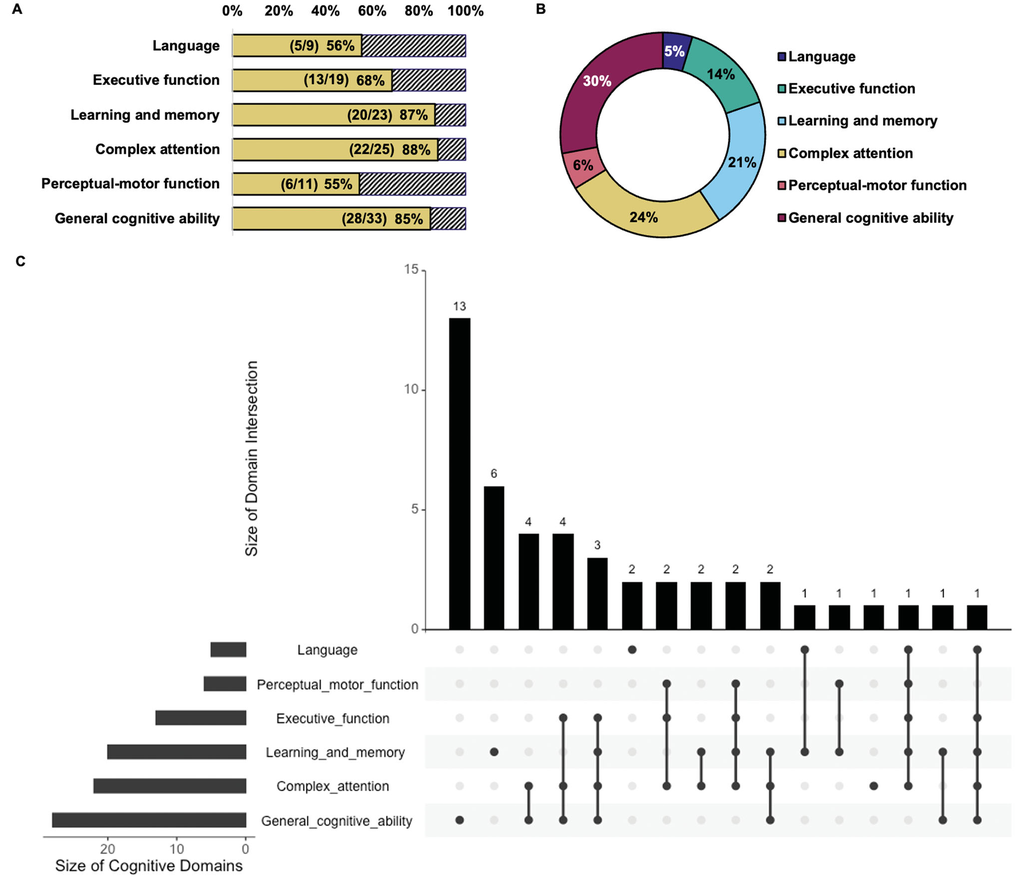

Figure 2. Current evidence on radiation-induced cognitive impairment in human studies. (a) Number of attempts and success rate for specific cognitive deficits

associated with brain irradiation. Each domain-specific success rate is determined by comparing the number of cases that successfully detects cognitive deficits

within its respective domain to the number of cases that sought out with the objective of detecting cognitive deficits within its respective domain. Studies may

have multiple cases of domain-specific cognitive deficits. (b) Domain-specific prevalence rates as determined by comparing the number of cases that successfully

detects cognitive deficits within its respective domain to the number of cases that successfully detects cognitive deficits for all domains. (c) Interaction between cog-

nitive domains. The ‘Size of Domain Intersection’ enumerates the studies that present evidence of their respective combination of cognitive deficit cases. The ‘Size

of Cognitive Domains’ enumerates the successfully detected cases of cognitive deficits within its respective domain.

5

microbleeds. Indeed, it has been shown that microbleeds

may disappear during clinical follow-up (Belliveau et al.

2017; Morrison et al. 2019) or that microbleeds could be

detected at all follow-up examinations upon appearance

(Peters et al. 2013; Lupo et al. 2016; Morrison et al. 2021).

Finally,

there

are

still

discrepancies

in

establishing

a

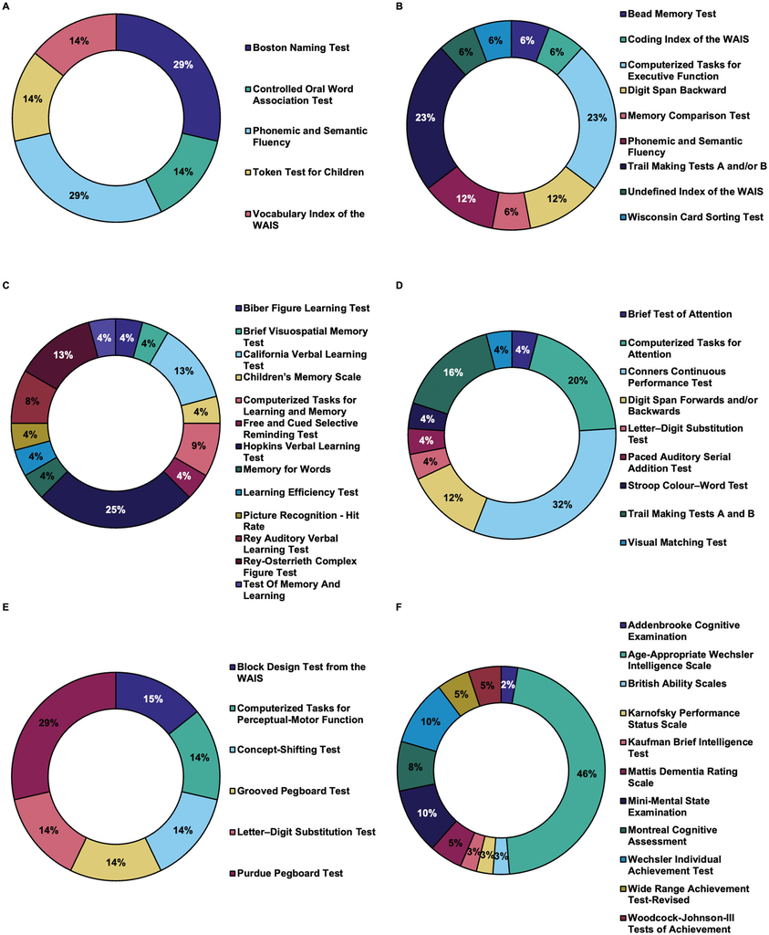

Figure 3. Assessments performed in human studies to measure changes in cognition after cranial radiotherapy. Illustrated in each subfigure are techniques that

successfully detected changes in cognition for the domains of: (a) language, (b) executive function, (c) learning and memory, (d) complex attention, (e) perceptual-

motor function, (f) general cognitive ability.

6

clinically feasible metabolic characteristic for RIBI. As previ-

ously mentioned, many MRS studies show that NAA/Cr

decreases after cranial irradiation with the assumption that

Cr remains stable over time. Due to a limited number of

studies, however, the change in Cr has yet to be determined.

A handful of studies show that it decreases within the irradi-

ated brain (Virta et al. 2000; Rueckriegel et al. 2012), how-

ever it is uncertain whether this is due to increasing age or

irradiation. Due to a limited number of studies, the change

in myoinositol normalized to creatine has yet to be deter-

mined. However, one study (Rutkowski et al. 2003) shows

that

it

increases

within

the

irradiated

brain.

Due

to

conflicting results, the effect of choline normalized to creat-

ine remains inconclusive. Indeed, studies have reported

increases (Rutkowski et al. 2003), decreases (Virta et al.

2000; Sundgren et al. 2009; Alirezaei et al. 2021), or no

changes (Usenius et al. 1995; Davidson et al. 2000; Wang

et al. 2012; Xiong et al. 2013) in choline normalized to cre-

atine post-irradiation.

Within this pool of 86 studies, there were 109 cumulative

attempts to measure MRI-detectable changes after cranial

radiotherapy from which 103 were successful in detecting

radiation-induced changes (Figure 4(a)). Pooling together

these 103 cases of successfully detected lesions, about 90% of

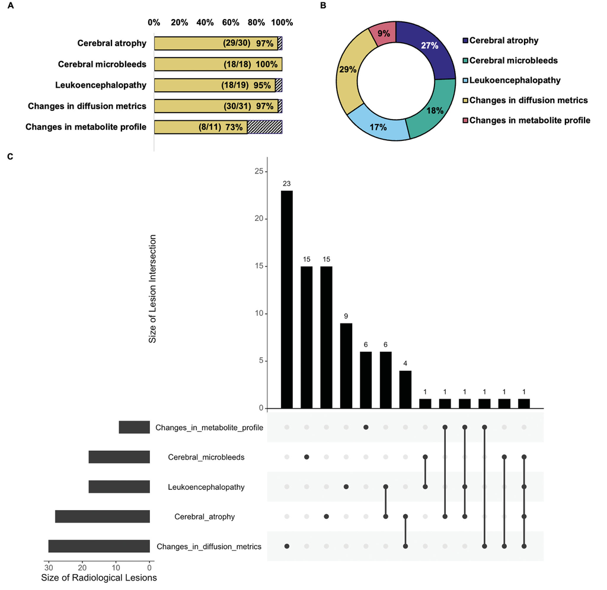

Figure 4. Current evidence on radiation-induced abnormalities as detected by magnetic resonance imaging in human studies. (a) Number of attempts and success

rate for specific radiological lesions associated with brain irradiation. Each lesion-specific success rate is determined by comparing the number of cases that success-

fully detected its respective radiological lesion to the number of cases that sought out with the objective of detecting its respective radiological lesion. Studies may

have multiple cases of radiologically detected lesions. (b) Lesion prevalence rates as determined by comparing the number of cases for each successfully detected

radiological lesion to the number of cases for all successfully detected radiological lesions. (c) Interaction between types of radiological lesions. The ‘Size of Lesion

Intersection’ enumerates the studies that present evidence of their respective combination of radiologically detected cases. The ‘Size of Radiological Lesions’ enu-

merates the successfully detected cases of the respective radiologically detected lesions.

7

the current viable evidence of MRI-detectable injuries in

human studies are composed of changes in cerebral atrophy,

cerebral microbleeds, leukoencephalopathy, changes in diffu-

sion metrics with minor evidence for the assessment of

changes in metabolite profile (Figure 4(b)). Furthermore, the

relationships between different forms of radiological RIBI

are more discrete than cognitive RIBI: most of these cases

of

radiologically

detected

lesions

occur

in

isolation

(Figure 4(c)). The studies in which these radiological lesions

are shown to occur by themselves did not attempt to meas-

ure other MRI-detectable changes.

While there is a multitude of evidence for radiological

RIBI, these results do not differ as much in the heterogen-

eity

of

assessments

as

compared

to

cognitive

RIBI

(Figure 5). In our dataset, for example, we find that 27% of

all radiologically detected lesions in humans are related to

cerebral atrophy, which are measured by 9 different types of

assessments. However, these variations in assessment types

are different from those used for cognitive RIBI. The assess-

ment types for radiological RIBI differ by level of detail pro-

vided compared to assessment types for cognitive RIBI.

For instance, 25% of cerebral atrophy studies used only

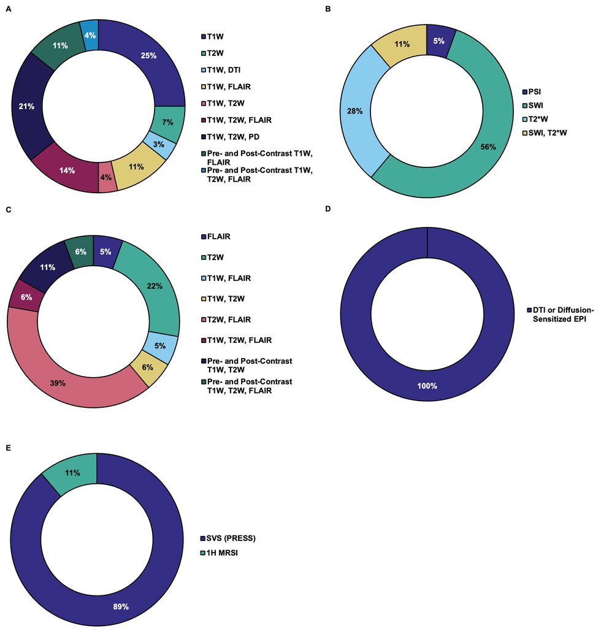

Figure 5. Magnetic resonance imaging techniques performed in human studies to detect lesions after cranial radiotherapy. Illustrated in each subfigure are techni-

ques that successfully detected lesion types such as: (a) cerebral atrophy, (b) cerebral microbleeds, (c) leukoencephalopathy, (d) changes in diffusion metrics, (e)

changes in metabolic profile.

8

T1-weighted imaging while 21% used a combination of

T1-weighted,

T2-weighted,

and

proton

density

images.

Volume loss will still be measured in these two circumstan-

ces, regardless of which combination of MRI protocols is

used. The difference, however, is that the accuracy ascribed

to cerebral volume loss is strengthened as more techniques

are used. In other words, the different types of cognitive

RIBI assessments measures different aspects of cognitive

domain impairment while different types of radiological

RIBI assessments measure the same result with different lev-

els of exactness. While we can form a general deduction

about the types of radiological RIBI cases (Figure 4(b)) and

connections of radiological RIBI (Figure 4(c)), firm numer-

ical end points cannot be concluded for all aforementioned

studies due to discrepancies in study methodology and data

presentation.

There is an association between cognitive and

radiological radiation-induced brain injury, but their

causative relationship remains unclear

We found a total of 29 studies that provided evidence of

both cognitive and radiological RIBI within a single human

cohort. The design, evidence type, and results of each study

are provided in S3 Table. The following relationships

between radiological lesions and cognitive impairments were

found in these patients that underwent cranial radiation

therapy: (1) loss of intracranial volume is associated with

poor cognitive status (Davidson et al. 2000; Mulhern et al.

2001; Reddick et al. 2003; Mulhern et al. 2004; Douw et al.

2009; Riggs et al. 2014; Reddick et al. 2014; Edelmann et al.

2014; Rashid et al. 2017; Bompaire et al. 2018; Tringale et al.

2019; Lin et al. 2021); (2) abnormalities in diffusion imaging

is associated with poor cognitive status (Khong et al. 2006;

Chapman et al. 2012; Schuitema et al. 2013; Edelmann et al.

2014; King et al. 2015; Chapman et al. 2016; Sim�o et al.

2016; Redmond et al. 2018; Bompaire et al. 2018; Tringale

et al. 2019; Tibbs et al. 2020); (3) WM hyperintensities (leu-

koencephalopathy) are associated with poor cognitive status

(Davidson et al. 2000; Douw et al. 2009; Correa et al. 2012;

Bompaire et al. 2018); and (4) cerebral microbleeds are asso-

ciated with cognitive decline (Roddy et al. 2016; Bompaire

et al. 2018; Morrison et al. 2021).

While these general relationships have been elucidated, it

is imperative to also consider other findings of cognitive

and radiological RIBI development from the systematic

review that do not fit within these trends. While there is evi-

dence that cerebral microbleeds are associated with worse

cognitive function, three other similar studies included in

this systematic review report that there were no clinical or

neurocognitive symptoms related to cerebral microbleeds

(Varon et al. 2014; Passos et al. 2015; Phillips et al. 2020).

For leukoencephalopathy, the study by Aoyama et al. reports

that only patients with severe white matter injury show clin-

ically meaningful signs of cognitive deterioration. However,

this cognitive outcome was assessed using the mini-mental

state examination, which is not as sensitive toward post-

treatment changes in cognition compared to comprehensive

neuropsychological tests (Cramer et al. 2019). Most import-

antly, many of these studies do not investigate the temporal

relationship between cognitive and radiological RIBI. There

are four studies that focus on teasing apart this temporal

relationship by describing it from an imaging biomarker

perspective, showing that changes in diffusion metrics pre-

cede and predict cognitive outcomes (Khong et al. 2006;

Chapman et al. 2012; Chapman et al. 2016; Tringale et al.

2019). In addition, one study provides evidence that white

matter

hyperintensities

precede

the

onset

of

cognitive

decline over a period of 6 years post-irradiation (Armstrong

et al. 2002). Due to a lack of further evidence on the tem-

poral relationship between cognitive and radiological RIBI,

in addition to a lack of large studies with well-designed

methodologies, there remains to be a consensus on whether

radiologically detected injuries develop in tandem, precede,

or follow cognitive impairment.

While many components of cognitive and radiological

RIBI have been shown to be interconnected, there are cer-

tain relationships that draw more interest from the research

field than others. A large proportion of evidence on the

association between cognitive and radiological RIBI stems

from cerebral atrophy and its relationship to the domain of

complex attention (Figure 6(a)). However, this trend may

not be reflective of the true etiology of RIBI. That is, these

number of papers may also reflect the research field’s cur-

rent interest in studying cerebral atrophy and its relationship

to different cognitive domains. Similar thinking can be

applied to other types of radiological RIBI, such as radi-

ation-induced leukoencephalopathy and changes in diffusion

metrics, and their respective relationships with cognitive

outcomes. Upon controlling for collaborative groups, a

change in distribution of associations between cognitive and

radiological RIBI can be found; interestingly, the largest pro-

portion now stems from changes in diffusion metrics and its

relationship to the domain of learning and memory (Figure

6(b)). However, the inherent issue of inhomogeneous assess-

ments of the connection between cognitive and radiological

RIBI still remains, making it unclear whether one relation-

ship is inherently more important than the other. Therefore,

further comprehensive assessment of the cognitive and

radiological RIBI relationship is needed to elucidate their

role in causation of neurological deterioration.

Clinical findings are not fully represented in

rodent models

We found a total of 35 studies that provided evidence of

cognitive RIBI within a rodent sample. These rodent studies

exclusively reflect either learning and memory (Yoneoka

et al. 1999; Raber et al. 2004; Rola et al. 2004; Shi et al.

2006; Zhao et al. 2007; Brown et al. 2007, p. 200; Atwood

et al. 2007; Robbins et al. 2009; Acharya et al. 2009; Caceres

et al. 2010; Acharya et al. 2011; Nageswara Rao et al. 2011;

Warrington et al. 2012; Acharya et al. 2013; Belarbi et al.

2013; Jenrow et al. 2013; Parihar et al. 2014; Greene-

Schloesser et al. 2014; Forbes et al. 2014; Peiffer et al. 2014;

Acharya et al. 2014; Baulch et al. 2016; Acharya et al. 2016;

9

Sun et al. 2016; Acharya et al. 2016; Brown et al. 2016; Feng

et al. 2016; Bazyar et al. 2017; Allen et al. 2018; B�alentov�a

et al. 2018; Alexander et al. 2018; Perez et al. 2018; He et al.

2021)

or

executive

function

(Sahnoune

et

al.

2018;

Tang et al. 2019); they do not replicate the interconnection

of cognitive impairments measured in humans (Figure 7(a)).

Much

like

in

the

human

studies,

a

variety

of

behavioral

assays

are

used

to

evaluate

impairment

in

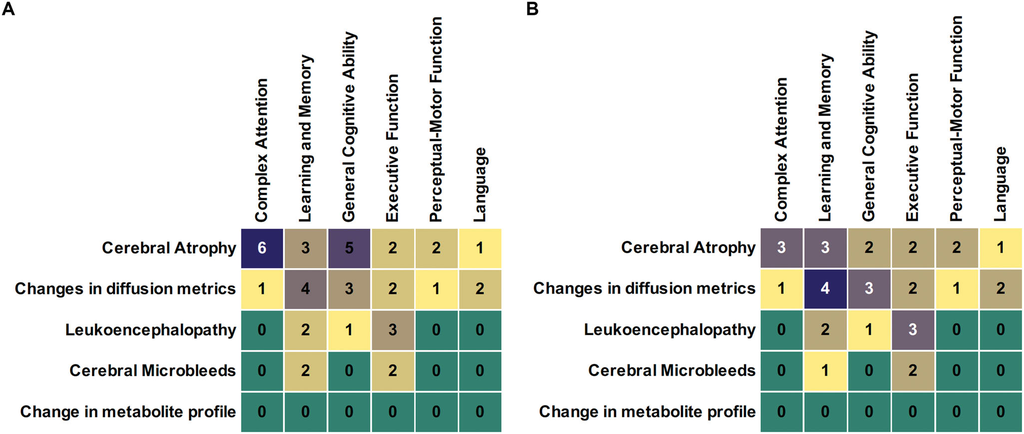

Figure 6. Associations between human studies containing evidence of both cognitive and radiological radiation-induced brain injuries. Number of (a) studies and

(b) research groups that have shown both cognitive and radiological RIBI in the same cohort. Dark blue values indicate a higher number of studies with respect to

the entire distribution while teal values indicate a lower number of studies.

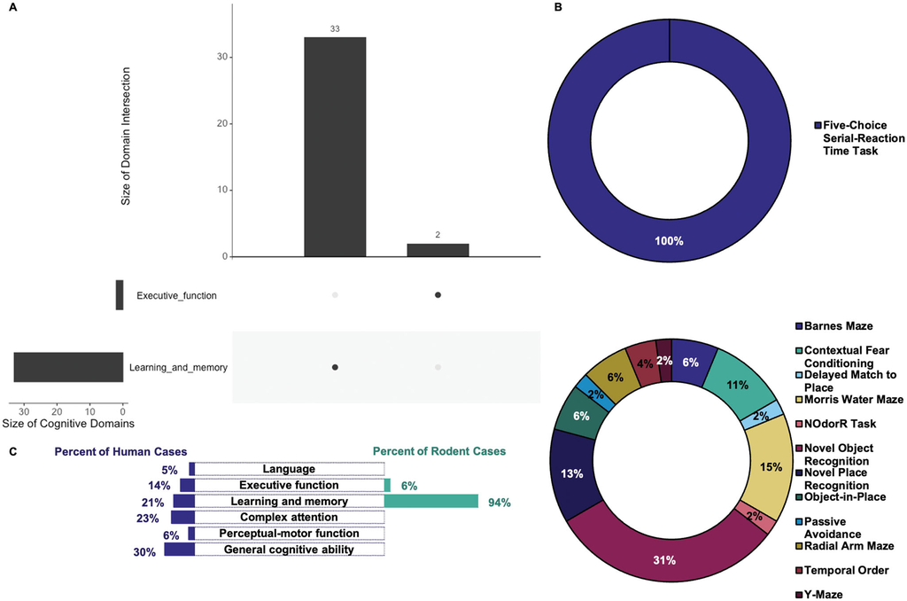

Figure 7. Current evidence on radiation-induced cognitive impairment in rodent studies. (a) Interaction between cognitive domains. The ‘Size of Domain

Intersection’ enumerates the studies that present evidence of their respective combination of cognitive deficit cases. The ‘Size of Cognitive Domains’ enumerates

the successfully detected cases of cognitive deficits within its respective domain. (b) Techniques that successfully detected changes in cognition for the domains of

(top) executive function and (bottom) learning and memory. (c) Distribution of cognitive domains assessed in rodents and humans after brain irradiation.

10

hippocampal-dependent learning and memory (Figure 7(b)).

While this cognitive domain is found to be impaired in

human patients, there is a clear mismatch between the focus

of cognitive assessment in human studies versus rodent

studies (Figure 7(c)). Similar to the issues that emerged in

human studies, it is unclear whether these trends are a result

of either (1) the true characteristic of cognitive impairment

in rodents, or (2) the inherent interests of researchers mod-

eling cognitive RIBI in humans. In other words, it is uncer-

tain whether our findings originate from the assumption

that either (1) rodent brains can only produce hippocampal-

dependent

learning

and

memory

impairments

post-

irradiation, or (2) we only see hippocampal-dependent

learning

and

memory

impairments

post-irradiation

in

rodents because that is the only area of injury that we are

measuring. As at least one group has found non-hippocam-

pal-dependent cognitive deficits in rodent RIBI models, the

latter assumption is more likely than the former.

We found a total of 19 studies that provided evidence of

radiological RIBI within a rodent sample. These rodent stud-

ies

identified

radiologically

detectable

lesions

such

as

changes in metabolite profile (Atwood et al. 2007; Rodgers

et al. 2016; Brown et al. 2016; Chen et al. 2017; B�alentov�a

et al. 2017; P�er�es et al. 2018; Hnilicov�a et al. 2019; B�alentov�a

et al. 2019; B�alentov�a et al. 2021), cerebral atrophy (Peiffer

et al. 2014; Sahnoune et al. 2018; Beera et al. 2018; Perez

et al. 2018; P�er�es et al. 2018; de Guzman et al. 2019; Tang

et al. 2019; He et al. 2021), and changes in diffusion metrics

(Wang et al. 2009; Wang et al. 2013; Liu et al. 2015;

Sahnoune et al. 2018; P�er�es et al. 2018; Tang et al. 2019);

the majority of these lesions are detected in isolation (Figure

8(a)). Furthermore, although the imaging techniques used to

detect these changes are similar to the protocols used for

humans (Figure 8(b)), the distribution of MRI-detectable

lesions in rodent models do not fully reflect the human

injury (Figure 8(c)). While neuroimaging studies of success-

ful models of cognition show evidence of cerebral atrophy

using anatomical MRI (Peiffer et al. 2014; Beera et al. 2018;

P�er�es et al. 2018; de Guzman et al. 2019) and DTI techni-

ques (Sahnoune et al. 2018; Perez et al. 2018; Tang et al.

2019), there are currently no rodent models that provide

evidence of radiation-induced leukoencephalopathy after

undergoing similar neuroimaging protocols as RIBI patients.

Likewise, there are no studies that perform neuroimaging

protocols to detect cerebral microbleeds within the rodent

brain, likely due to the increased susceptibility artifacts

when scanning rodent brains. With respect to rodent models

measuring microstructural and metabolic changes, evidence

is limited in number and remains inconclusive. While some

rodent models show a post-treatment decrease in FA, others

show FA remain unchanged post-treatment (Peiffer et al.

2014; Rodgers et al. 2016; Sahnoune et al. 2018; Perez et al.

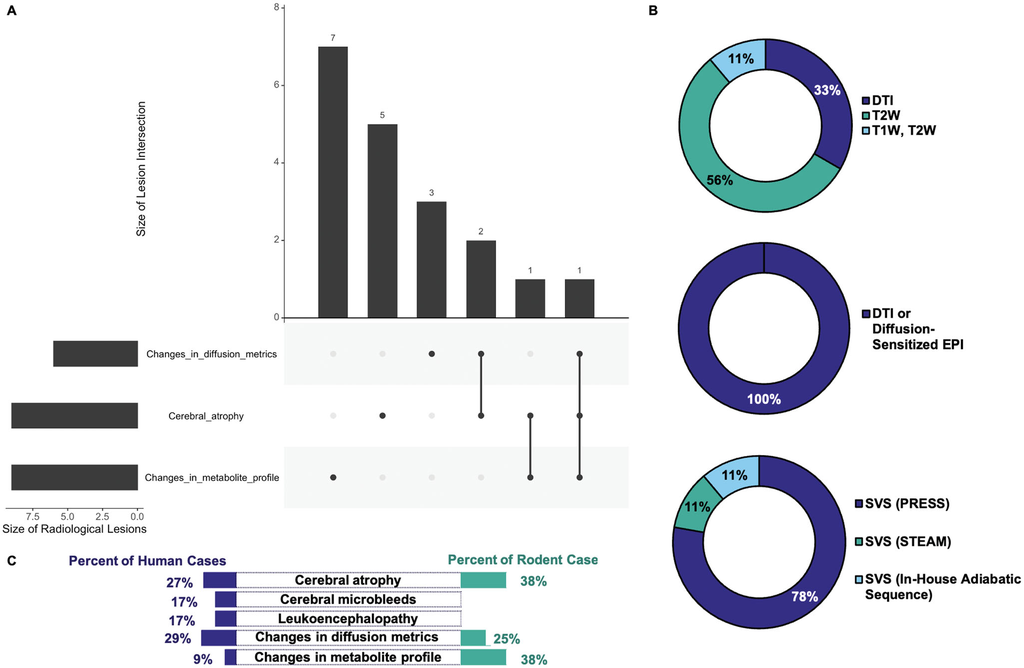

Figure 8. Current evidence on radiation-induced lesions detectable by magnetic resonance imaging in rodent studies. (a) Interaction between types of radiological

lesions. The ‘Size of Lesion Intersection’ enumerates the studies that present evidence of their respective combination of radiologically detected cases. The ‘Size of

Radiological Lesions’ enumerates the successfully detected cases of the respective radiologically detected lesions. (b) Techniques that successfully detected changes

in (top) cerebral atrophy, (middle) diffusion metrics, and (bottom) metabolite profile. (c) Distribution of radiological lesions assessed in rodents and humans after

brain irradiation.

11

2018) despite the occurrence of other cognitive changes

within the same cohort. Furthermore, while there is evidence

of metabolic-related changes in rodent brains, the evidence

contains many discrepancies. Neuroimaging assessments in

models of cognition show conflicting evidence of metabolic

changes within the rodent brain post-irradiation. NAA/Cr

has been shown to increase (Atwood et al. 2007; Rodgers

et al. 2016), decrease (Brown et al. 2016, p. 201; Chen et al.

2017; B�alentov�a et al. 2017; Hnilicov�a et al. 2019; B�alentov�a

et al. 2019; B�alentov�a et al. 2021), or have no change post-

irradiation (Robbins et al. 2009). Glutamate and glutamine

normalized

to

creatine

have

been

shown

to

increase

(Atwood et al. 2007), decrease (Brown et al. 2016; B�alentov�a

et al. 2021), or have no change post-irradiation (Robbins

et al. 2009; B�alentov�a et al. 2017). Choline normalized to

creatine has been shown to increase (B�alentov�a et al. 2021),

decrease (Chen et al. 2017; B�alentov�a et al. 2019), or have

no change post-irradiation (B�alentov�a et al. 2017; Hnilicov�a

et al. 2019). Myoinositol normalized to creatine has been

shown to increase (Hnilicov�a et al. 2019; B�alentov�a et al.

2021), decrease (Atwood et al. 2007; Rodgers et al. 2016), or

have no change (Robbins et al. 2009) post-irradiation.

We found seven studies that provided evidence of both

cognitive and radiological RIBI within a rodent sample. The

design, evidence type, and results of each study are pre-

sented in S4 Table. Two studies describe the relationship

between changes in executive functioning and diffusion met-

rics within rodents (Sahnoune et al. 2018; Tang et al. 2019)

while the other five studies present the connection between

learning and memory impairments and either cerebral atro-

phy (Peiffer et al. 2014; Perez et al. 2018; He et al. 2021) or

changes in metabolite profile (Atwood et al. 2007; Brown

et al. 2016). While these rodent studies have successfully

detected cognitive and radiological changes post-irradiation,

the current rodent models of RIBI do not holistically repli-

cate

the

research

findings

currently

exhibited

in

human cases.

Discussion

This systematic review of the literature was conducted to

evaluate the characteristics of current late-delayed RIBI stud-

ies, elucidate the connections between cognitive and radio-

logical forms of late-delayed RIBI, and report the accuracy

of current rodent models. Regarding the features of human

cognitive RIBI, there are many attempts to measure deficits

within the domains of general cognitive ability, complex

attention, or learning and memory. In comparison, there are

not as many attempts to measure changes in language, per-

ceptual-motor function, or executive function. Additionally,

the success rate of cognitive domain deficit detection gener-

ally reflects the number of attempts to measure cognitive

domain deficits. That is, the domain deficits that contribute

the entirety of cognitive RIBI consist of those that are more

widely sought out to assessed, such as general cognitive abil-

ity and complex attention. Regarding the features of human

radiological RIBI, there are many attempts to measure cere-

bral atrophy, cerebral microbleeds, leukoencephalopathy,

and changes in diffusion metrics. However, there are not as

many attempts to measure changes in metabolite profile.

Additionally, each type of radiological lesion has a perfect

success rate except for cerebral atrophy.

With respect to the trends between cognitive and radio-

logical RIBI, our results show that there is a high distribu-

tion of studies that focus on the association between

cerebral atrophy and complex attention. However, certain

associations between cognitive domain deficits (e.g., percep-

tual-motor

function

and

language)

and

radiologically

detected lesions (e.g. leukoencephalopathy, cerebral micro-

bleeds, and changes in metabolite profile) remain largely

undefined. It is thus unclear whether these trends are due to

implicit relationships between cognitive and radiological

RIBI or to predispositions in research interests.

Incongruency is further reflected in the current preclin-

ical models of RIBI. Results from rodent studies show that

there are a limited number of models that have successfully

replicated characteristics of cognitive and radiological RIBI

as it would occur in a human. In the case of cognitive

impairment, it is shown in this review that most rodent

models of cognition replicate hippocampal-dependent learn-

ing and memory – only one of the many aspects of human

cognitive impairment. Further consideration of cognitive

assessments performed in rodent studies suggests that the

high number of results for hippocampal-dependent memory

impairment may be driven by a lack of comprehensive

assays in rodent models of RIBI. In addition, results from

rodent models of neuroimaging are not completely consist-

ent with what is observed in humans. Most of the evidence

for radiological RIBI in rodents is derived from cases of

cerebral atrophy and changes in metabolite profile, with a

minor contribution from changes in diffusion metrics.

While these radiological lesions are also present in humans,

there is no current evidence that rodents are capable of

exhibiting further characteristic lesions observed in humans,

such as radiation-induced leukoencephalopathy and cerebral

microbleeds. However, the lack of cerebral microbleed detec-

tion may be driven by a lack of MR techniques and hard-

ware compatible with small animals.

The primary limitation of our systematic review is a

lack of quantitative analysis of our results. However, a

meta-analysis could not be performed due to the hetero-

geneity of study methodology and data presentation. There

was a wide variety of study designs, patient demographics,

outcome measurement techniques, and follow-up times

after treatment. In some studies, particular components of

methodology were completely omitted. Furthermore, other

study characteristics such as irradiated volume, total dose,

number of treatment fractions, and raw outcome scores

were

not

consistently

provided

within

the

methods.

Regarding heterogeneity in the presentation of data, many

human studies with mixed patient demographics (e.g.

mixed treatment cohorts of radiotherapy only and radio-

therapy with chemotherapy) present results in an unstrati-

fied manner such that it was difficult to deduce which side

effects

were

derived

solely

from

radiotherapy.

Additionally,

some

studies

reported

wide

ranges

of

outcome measurement (e.g. 6–60 months post-treatment)

without stratification of results in regard to its specific

time point of presentation. Due to these challenges in

combining and comparing the collected data in a system-

atic fashion, it became clear that a meta-analysis would

not provide an accurate insight into the current data.

A limitation of our qualitative analysis of the literature is

that patient demographics, irradiated volume, and radiation

dose were not considered in the analysis of late-delayed

effects of RIBI. This is because treatment effects were not

given with respect to patient age or sex, but rather as an

entire cohort. Additionally, there were high variations in

treatment protocols, which are unique to the patient’s dis-

ease presentation and progression. For these reasons, the

late-delayed effects of RIBI were investigated holistically

based on the evidence made available by a systematic review

of the literature. In addition, we do not know how many

inconclusive or negative findings have been discovered but

not published. It is also possible that other studies concern-

ing the late-delayed effects of RIBI in humans and rodents

were published but were not within the scope of our

search strategy.

Evidence from our review shows that rodent models are

limited in replicating the multitude of cognitive impairments

observed in humans due to constraints in the availability of

verified cognitive assessments. A suggestion would be to

consider the use of additional cognitive assessments for

rodent models that have been performed outside the field of

rodent RIBI models. For instance, rodent studies of space

radiation-induced cognitive impairment have successfully

modeled metacognitive and hypothesis-generating tasks that

were previously assumed to be primate-specific (Britten

et al. 2021). Aside from rodent models, intermediate animal

models may also have the potential to replicate human out-

comes. Notably, non-human primates (Robbins et al. 2011;

Hanbury

et

al.

2015;

Andrews

et

al.

2019),

swine

(Athanasiadi et al. 2021), and dogs (Benczik et al. 2002)

have been shown to be feasible large animal models of RIBI.

Overall, it may be ideal to consider either alternative cogni-

tive assessments for rodent models or different model sys-

tems in order to replicate the human characteristics of

cognitive and radiological RIBI more closely.

An additional suggestion for future research is to create a

protocol of standardized assessments in order to maintain

reproducible results in multi-center clinical trials of RIBI

therapeutics. Our systematic review shows there are many

successful methods to assess impairment within a neurocog-

nitive domain: 5 different tests identified language impair-

ment, 9 for executive function, 13 for learning and memory,

9 for complex attention, 6 for perceptual-motor function,

and 11 for general cognitive ability. While this diversity in

assessment type allows for different facets of cognitive

impairment to be measured and analyzed, it also creates

issues in maintaining consistency within the field of RIBI.

Along with standardization, it is also important that these

assessments accommodate the practicalities of clinical fol-

low-up procedures. For instance, these evaluations should be

simple without sacrificing sensitivity and able to be quickly

performed by non-specialists (Durand et al. 2015).

Lastly, it is important to begin incorporating the use of

more functional rather than structural MRI techniques in

studies of RIBI, such as functional MRI (van den Heuvel

and Hulshoff Pol 2010) and functional connectivity (Zhao

et al. 2021). As noted above, cognitive deficits have been

identified in rodent space radiation models at doses much

lower than those explored for RIBI. These deficits are

believed to occur without overt structural changes. Similarly,

some rodent RIBI reports indicate cognitive deficits without

corresponding structural changes (Shi et al. 2009; Rancilio

et al. 2017). However, as we noted in our section regarding

the relationship between cognitive and radiological deficits,

no human study of RIBI that has evaluated both cognitive

and radiological changes have found cognitive deficits with-

out corresponding radiological changes. There are multiple

possible explanations for this discrepancy between human

cases and rodent models. But if the thought is that the cog-

nitive deficits that characterize RIBI are due to functional

changes that precede the structural changes, then the use of

functional imaging can help make that clearer. Together, the

use of more sensitive imaging techniques and standardized

neurocognitive assessments would provide a greatly needed

holistic approach to understanding the complete spectrum

of late-delayed RIBI in brain cancer survivors.

In summary, the associations between and within cogni-

tive and radiological RIBI often rely on the type of assess-

ment

chosen

to

detect

it.

Indeed,

inhomogeneous

assessments of RIBI subcomponents can result in inhomo-

geneous manifestations of RIBI subcomponents. This theme

of heterogeneity eventually pervades into preclinical animal

modeling, creating rodent studies that assay only certain

subcomponents of RIBI. Rather than placing consideration

for only certain subcomponents of RIBI, perhaps it is just as

important to evaluate the totality of known effects to realize

the full consequence of RIBI.

Disclosure statement

The authors report there are no competing interests to declare.

Funding

This publication was made possible, in part, thanks to financial support

from the Ralph W. and Grace M. Showalter Research Trust at

Purdue University.

Notes on contributors

Whitney D. Perez is currently a Scientific Communications Scientist at

Cook Research Incorporated. She received her PhD in 2022 from

Purdue University where she investigated the side effects of cranial

radiation therapy within a mini-pig model using advanced MRI and

histological techniques. She received her BS and MS degree in 2017

and 2018, respectively, from Purdue University’s Radiological Health

Pre-Medical Physics 4 þ 1 Graduate Program.

Carlos J. Perez-Torres is currently a Collegiate Associate Professor in

the Academy of Integrated Science at Virginia Polytechnic Institute

and State University. He received his PhD in 2012 from Baylor College

of Medicine where he explored the development of MRI techniques for

use in rodent models. Dr. Perez-Torres has 10 years of experience on

the use of MRI methods to track the effects of radiation in the murine

brain. His most recent work expands this murine work to a novel pig

model of radiation-induced brain injury.

ORCID

Carlos J. Perez-Torres

http://orcid.org/0000-0003-3352-011X

References

Acharya MM, Baulch JE, Lusardi TA, Allen BD, Chmielewski NN,

Baddour AAD, Limoli CL, Boison D. 2016. Adenosine kinase inhib-

ition protects against cranial radiation-induced cognitive dysfunc-

tion. Front Mol Neurosci. 9:42.

Acharya MM, Christie L-A, Hazel TG, Johe KK, Limoli CL. 2014.

Transplantation of human fetal-derived neural stem cells improves

cognitive function following cranial irradiation. Cell Transplant.

23(10):1255–1266.

Acharya MM, Christie L-A, Lan ML, Donovan PJ, Cotman CW, Fike

JR, Limoli CL. 2009. Rescue of radiation-induced cognitive impair-

ment through cranial transplantation of human embryonic stem

cells. Proc Natl Acad Sci USA. 106(45):19150–19155.

Acharya MM, Christie L-A, Lan ML, Giedzinski E, Fike JR, Rosi S,

Limoli CL. 2011. Human neural stem cell transplantation amelio-

rates radiation-induced cognitive dysfunction. Cancer Res. 71(14):

4834–4845.

Acharya MM, Christie L-A, Lan ML, Limoli CL. 2013. Comparing the

functional consequences of human stem cell transplantation in the

irradiated rat brain. Cell Transplant. 22(1):55–64.

Acharya MM, Green KN, Allen BD, Najafi AR, Syage A, Minasyan H,

Le MT, Kawashita T, Giedzinski E, Parihar VK, et al. 2016.

Elimination of microglia improves cognitive function following cra-

nial irradiation. Sci Rep. 6(1):31545.

Agbahiwe H, Rashid A, Horska A, Mahone EM, Lin D, McNutt T,

Cohen K, Redmond K, Wharam M, Terezakis S. 2017. A prospective

study of cerebral, frontal lobe, and temporal lobe volumes and

neuropsychological performance in children with primary brain

tumors treated with cranial radiation: brain volumes and neuro-

psychological assessment. Cancer. 123(1):161–168.

Ajithkumar T, Price S, Horan G, Burke A, Jefferies S. 2017. Prevention

of radiotherapy-induced neurocognitive dysfunction in survivors of

paediatric brain tumours: the potential role of modern imaging and

radiotherapy techniques. Lancet Oncol. 18(2):e91–e100.

Alexander TC, Butcher H, Krager K, Kiffer F, Groves T, Wang J,

Carter G, Allen AR. 2018. Behavioral effects of focal irradiation in a

Juvenile murine model. Radiat Res. 189(6):605–617.

Alirezaei Z, Amouheidari A, Hassanpour M, Davanian F, Iraji S,

Shokrani P, Nazem-Zadeh M-R. 2021. Early detection of radiation-

induced injury and prediction of cognitive deficit by MRS metabo-

lites in radiotherapy of low-grade Glioma.Bunevicius A, editor.

Biomed Res Int. 2021:6616913–6616992.

Allen BD, Acharya MM, Lu C, Giedzinski E, Chmielewski NN, Quach

D, Hefferan M, Johe KK, Limoli CL. 2018. Remediation of radi-

ation-induced cognitive dysfunction through oral administration of

the neuroprotective compound NSI-189. Radiat Res. 189(4):345–353.

Andersen PB, Krabbe K, Leffers AM, Schmiegelow M, Holm S,

Laursen H, Muller JR, Paulson OB. 2003. Cerebral glucose metabol-

ism in long-term survivors of childhood primary brain tumors

treated with surgery and radiotherapy. 9.

Anderson V, Godber T, Smibert E, Ekert H. 1997. Neurobehavioural

sequelae following cranial irradiation and chemotherapy in children:

an analysis of risk factors. Pediatr Rehabil. 1(2):63–76.

Andrews RN, Dugan GO, Peiffer AM, Hawkins GA, Hanbury DB,

Bourland JD, Hampson RE, Deadwyler SA, Cline JM. 2019. White

matter is the predilection site of late-delayed radiation-induced brain

injury in non-human primates. Radiat Res. 191(3):217.

Aoyama H, Tago M, Kato N, Toyoda T, Kenjyo M, Hirota S, Shioura

H, Inomata T, Kunieda E, Hayakawa K, et al. 2007. Neurocognitive

function of patients with brain metastasis who received either whole

brain radiotherapy plus stereotactic radiosurgery or radiosurgery

alone. Int J Radiat Oncol Biol Phys. 68(5):1388–1395.

Armstrong CL, Fisher MJ, Li Y, Lustig RA, Belasco JB, Minturn JE,

Hill-Kayser CE, Batra S, Phillips PC. 2016. Neuroplastic response

after radiation therapy for pediatric brain tumors: a pilot study. Int

J Radiat Oncol Biol Phys. 95(3):991–998.

Armstrong CL, Hunter JV, Ledakis GE, Cohen B, Tallent EM,

Goldstein BH, Tochner Z, Lustig R, Judy KD, Pruitt A, et al. 2002.

CME Late cognitive and radiographic changes related to radiother-

apy. 10.

Athanasiadi I, Perez WD, Plantenga JM, Jones-Hall Y, Perez-Torres CJ.

2021. Feasibility of a mini-pig model of radiation-induced brain

injury to one cerebral hemisphere. Radiat Oncol. 16(1):30.

Atwood T, Payne VS, Zhao W, Brown WR, Wheeler KT, Zhu J-M,

Robbins ME. 2007. Quantitative magnetic resonance spectroscopy

reveals a potential relationship between radiation-induced changes

in rat brain metabolites and cognitive impairment. Radiat Res.

168(5):574–581.

B�alentov�a S, Hajtmanov�a E, Filov�a B, Borb�elyov�a V, Lehotsk�y J,

Adamkov M. 2018. Effects of fractionated whole-brain irradiation

on cellular composition and cognitive function in the rat brain. Int J

Radiat Biol. 94(3):238–247.

B�alentov�a S, Hnilicov�a P, Kalensk�a D, Baranovi�cov�a E, Mur�ı�n P,

Bitt�sansk�y M, Hajtmanov�a E, Lehotsk�y J, Adamkov M. 2019.

Metabolic and histopathological changes in the brain and plasma of

rats exposed to fractionated whole-brain irradiation. Brain Res.

1708:146–159.

B�alentov�a S, Hnilicov�a P, Kalensk�a D, Baranovi�cov�a E, Mur�ı�n P,

Hajtmanov�a E, Adamkov M. 2021. Effect of fractionated whole-

brain irradiation on brain and plasma in a rat model: metabolic,

volumetric and histopathological changes. Neurochem Int. 145:

104985.

B�alentov�a S, Hnilicov�a P, Kalensk�a D, Mur�ın P, Hajtmanov�a E,

Lehotsk�y J, Adamkov M. 2017. Effect of whole-brain irradiation on

the specific brain regions in a rat model: Metabolic and histopatho-

logical changes. NeuroToxicology. 60:70–81.

Baulch

JE,

Acharya

MM,

Allen

BD,

Ru

N,

Chmielewski

NN,

Martirosian V, Giedzinski E, Syage A, Park AL, Benke SN, et al.

2016. Cranial grafting of stem cell-derived microvesicles improves

cognition and reduces neuropathology in the irradiated brain. Proc

Natl Acad Sci USA. 113(17):4836–4841.

Bazyar S, Inscoe CR, Benefield T, Zhang L, Lu J, Zhou O, Lee YZ.

2017. Neurocognitive sparing of desktop microbeam irradiation.

Radiat Oncol. 12(1):127.

Beera KG, Li Y-Q, Dazai J, Stewart J, Egan S, Ahmed M, Wong CS,

Jaffray DA, Nieman BJ. 2018. Altered brain morphology after focal

radiation reveals impact of off-target effects: implications for white

matter development and neurogenesis. Neuro Oncol. 20(6):788–798.

Belarbi K, Jopson T, Arellano C, Fike JR, Rosi S. 2013. CCR2 defi-

ciency prevents neuronal dysfunction and cognitive impairments

induced by cranial irradiation. Cancer Res. 73(3):1201–1210.

Belliveau J-G, Bauman GS, Tay KY, Ho D, Menon RS. 2017. Initial

investigation into microbleeds and white matter signal changes fol-

lowing radiotherapy for low-grade and benign brain tumors using

ultra-high-field MRI techniques. AJNR Am J Neuroradiol. 38(12):

2251–2256.

Benczik J, Tenhunen M, Snellman M, Joensuu H, F€arkkil€a M, Joensuu

R, Abo Ramadan U, Kallio M, deGritz B, Morris GM, et al. 2002.

Late radiation effects in the dog brain: correlation of MRI and histo-

logical changes. Radiother Oncol. 63(1):107–120.

Bian Y, Meng L, Peng J, Li J, Wei R, Huo L, Yang H, Wang Y, Fu J,

Shen L, et al. 2019. Effect of radiochemotherapy on the cognitive

function and diffusion tensor and perfusion weighted imaging for

high-grade gliomas: a prospective study. Sci Rep. 9(1):5967.

Bompaire F, Lahutte M, Buffat S, Soussain C, Ardisson AE, Terziev R,

Sallansonnet-Froment M, De Greslan T, Edmond S, Saad M, et al.

2018. New insights in radiation-induced leukoencephalopathy: a

prospective cross-sectional study. Support Care Cancer. 26(12):

4217–4226.

Britten RA, Wellman LL, Sanford LD. 2021. Progressive increase in the

complexity and translatability of rodent testing to assess space-radi-

ation induced cognitive impairment. Neurosci Biobehav Rev. 126:

159–174.

Brown PD, Gondi V, Pugh S, Tome WA, Wefel JS, Armstrong TS,

Bovi

JA,

Robinson

C,

Konski

A,

Khuntia

D,

et

al.

2020.

Hippocampal avoidance during whole-brain radiotherapy plus mem-

antine for patients with brain metastases: Phase III Trial NRG

Oncology CC001. J Clin Oncol. 38(10):1019–1029.

Brown RJ, Jun BJ, Cushman JD, Nguyen C, Beighley AH, Blanchard J,

Iwamoto K, Schaue D, Harris NG, Jentsch JD, et al. 2016. Changes

in imaging and cognition in juvenile rats after whole-brain irradi-

ation. Int J Radiat Oncol Biol Phys. 96(2):470–478.

Brown WR, Blair RM, Moody DM, Thore CR, Ahmed S, Robbins ME,

Wheeler KT. 2007. Capillary loss precedes the cognitive impairment

induced by fractionated whole-brain irradiation: A potential rat

model of vascular dementia. J Neurol Sci. 257(1-2):67–71.

Burns TC, Awad AJ, Li MD, Grant GA. 2016. Radiation-induced brain

injury: low-hanging fruit for neuroregeneration. Neurosurg Focus.

40(5):E3.

Butler RW, Fairclough DL, Katz ER, Kazak AE, Noll RB, Thompson

RD, Sahler OJZ. 2013. Intellectual functioning and multi-dimen-

sional attentional processes in long-term survivors of a central ner-

vous system related pediatric malignancy. Life Sci. 93(17):611–616.

Caceres LG, Aon Bertolino L, Saraceno GE, Zorrilla Zubilete MA,

Uran SL, Capani F, Guelman LR. 2010. Hippocampal-related mem-

ory deficits and histological damage induced by neonatal ionizing

radiation exposure. Role of oxidative status. Brain Res. 1312:67–78.

Capilla-Gonzalez V, Bonsu JM, Redmond KJ, Garcia-Verdugo JM,

Qui~nones-Hinojosa A. 2016. Implications of irradiating the subven-

tricular zone stem cell niche. Stem Cell Res. 16(2):387–396.

Chang EL, Wefel JS, Hess KR, Allen PK, Lang FF, Kornguth DG,

Arbuckle

RB,

Swint

JM,

Shiu

AS,

Maor

MH,

et

al.

2009.

Neurocognition in patients with brain metastases treated with radio-

surgery or radiosurgery plus whole-brain irradiation: a randomised

controlled trial. Lancet Oncol. 10(11):1037–1044.

Chapman CH, Buchtel H, Lawrence TS. 2012. Diffusion tensor imaging

of normal-appearing white matter as biomarker for radiation-

induced late delayed cognitive decline. Int J Radiat Oncol Biol Phys

82(5):8.

Chapman CH, Zhu T, Nazem-Zadeh M, Tao Y, Buchtel HA, Tsien CI,

Lawrence TS, Cao Y. 2016. Diffusion tensor imaging predicts cogni-

tive function change following partial brain radiotherapy for low-

grade and benign tumors. Radiotherapy Oncol. 120(2):234–240.

Chen H, Cheng Y-S, Zhou Z-R. 2017. Long-term brain tissue monitor-

ing after semi-brain irradiation in rats using proton magnetic reson-

ance spectroscopy: a preliminary study in vivo. Chin Med J. 130(8):

957–963.

Connor M, Karunamuni R, McDonald C, Seibert T, White N,

Moiseenko V, Bartsch H, Farid N, Kuperman J, Krishnan A, et al.

2017. Regional susceptibility to dose-dependent white matter dam-

age after brain radiotherapy. Radiotherapy Oncol. 123(2):209–217.

Connor M, Karunamuni R, McDonald C, White N, Pettersson N,

Moiseenko V, Seibert T, Marshall D, Cervino L, Bartsch H, et al.

2016. Dose-dependent white matter damage after brain radiotherapy.

Radiotherapy Oncol. 121(2):209–216.

Corn BW, Moughan J, Knisely JPS, Fox SW, Chakravarti A, Yung

WKA, Curran WJ, Robins HI, Brachman DG, Henderson RH, et al.

2008. Prospective evaluation of quality of life and neurocognitive

effects in patients with multiple brain metastases receiving whole-

brain radiotherapy with or without thalidomide on Radiation

Therapy Oncology Group (RTOG) Trial 0118. Int J Radiat Oncol

Biol Phys. 71(1):71–78.

Correa DD, Shi W, Abrey LE, DeAngelis LM, Omuro AM, Deutsch

MB, Thaler HT. 2012. Cognitive functions in primary CNS lymph-

oma after single or combined modality regimens. Neuro Oncol.

14(1):101–108.

Cramer CK, Cummings TL, Andrews RN, Strowd R, Rapp SR, Shaw

EG, Chan MD, Lesser GJ. 2019. Treatment of radiation-induced

cognitive decline in adult brain tumor patients. Curr Treat Options

Oncol. 20(5):42.

Davidson A, Tait DM, Payne GS, Hopewell JW, Leach MO, Watson

M, MacVicar AD, Britton JA, Ashley S. 2000. Magnetic resonance

spectroscopy in the evaluation of neurotoxicity following cranial

irradiation for childhood cancer. Br J Radiol. 73(868):421–424.

Diaz AZ, Choi M. 2014. Radiation-associated toxicities in the treatment

of high-grade gliomas. Semin Oncol. 41(4):532–540.

Dietrich J, Monje M, Wefel J, Meyers C. 2008. Clinical patterns and

biological correlates of cognitive dysfunction associated with cancer

therapy. Oncologist. 13(12):1285–1295.

Douw L, Klein M, Fagel SS, van den Heuvel J, Taphoorn MJ,

Aaronson NK, Postma TJ, Vandertop WP, Mooij JJ, Boerman RH,

et al. 2009. Cognitive and radiological effects of radiotherapy in

patients with low-grade glioma: long-term follow-up. Lancet Neurol.

8(9):810–818.

Duan F, Cheng J, Jiang J, Chang J, Zhang Y, Qiu S. 2016. Whole-brain

changes in white matter microstructure after radiotherapy for naso-

pharyngeal carcinoma: a diffusion tensor imaging study. Eur Arch

Otorhinolaryngol. 273(12):4453–4459.

Durand T, Bernier M-O, L�eger I, Taillia H, No€el G, Psimaras D,

Ricard D. 2015. Cognitive outcome after radiotherapy in brain

tumor. Curr Opin Oncol. 27(6):510–515.

Edelmann MN, Krull KR, Liu W, Glass JO, Ji Q, Ogg RJ, Sabin ND,

Srivastava DK, Robison LL, Hudson MM, et al. 2014. Diffusion ten-

sor imaging and neurocognition in survivors of childhood acute

lymphoblastic leukaemia. Brain. 137(11):2973–2983.

Faraci M, Morana G, Bagnasco F, Barra S, Polo P, Hanau G, Fioredda

F, Caruso S, Rossi A, Spaziante R, et al. 2011. Magnetic resonance

imaging in childhood leukemia survivors treated with cranial radio-

therapy: a cross sectional, single center study. Pediatr Blood Cancer.

57(2):240–246.

Feng X, Jopson TD, Paladini MS, Liu S, West BL, Gupta N, Rosi S.

2016. Colony-stimulating factor 1 receptor blockade prevents fractio-

nated

whole-brain

irradiation-induced

memory

deficits.

J

Neuroinflamm. 13(1):215.

Fike JR, Rosi S, Limoli CL. 2009. Neural precursor cells and central

nervous system radiation sensitivity. Semin Radiat Oncol. 19(2):

122–132.

brain metabolism and neurocognitive function in childhood leuke-

mia survivors despite complete hormone supplementation in adult-

hood. Psychoneuroendocrinology. 73:157–165.

Follin C, Sv€ard D, van Westen D, Bj€orkman-Burtscher IM, Sundgren

PC, Fjalldal S, L€att J, Nilsson M, Johanson A, Erfurth EM. 2019.

Microstructural white matter alterations associated to neurocognitive

deficits in childhood leukemia survivors treated with cranial radio-

therapy – a diffusional kurtosis study. Acta Oncol. 58(7):1021–1028.

Forbes ME, Paitsel M, Bourland JD, Riddle DR. 2014. Early-delayed,

radiation-induced cognitive deficits in adult rats are heterogeneous

and age-dependent. Radiat Res. 182(1):60–71.

Giglio P, Gilbert MR. 2003. Cerebral radiation necrosis. Neurologist.

9(4):180–188.

Greene-Schloesser D, Moore E, Robbins ME. 2013. Molecular path-

ways: radiation-induced cognitive impairment. Clin Cancer Res.

19(9):2294–2300.

Greene-Schloesser D, Payne V, Peiffer AM, Hsu F-C, Riddle DR, Zhao

W, Chan MD, Metheny-Barlow L, Robbins ME. 2014. The peroxi-

somal proliferator-activated receptor (PPAR) a agonist, fenofibrate,

prevents

fractionated

whole-brain

irradiation-induced

cognitive

impairment. Radiat Res. 181(1):33–44.

Greene-Schloesser D, Robbins ME. 2012. Radiation-induced cognitive

impairment-from bench to bedside. Neuro-Oncology. 14(suppl 4):

iv37–iv44.

Greene-Schloesser D, Robbins ME, Peiffer AM, Shaw EG, Wheeler KT,

Chan MD. 2012. Radiation-induced brain injury: a review. Front

Oncol. 2:73.

de Guzman AE, Ahmed M, Li Y-Q, Wong CS, Nieman BJ. 2019. p53

loss mitigates early volume deficits in the brains of irradiated young

mice. Int J Radiat Oncol Biol Phys. 103(2):511–520.

Haller S, Vernooij MW, Kuijer JPA, Larsson E-M, J€ager HR, Barkhof

F. 2018. Cerebral microbleeds: imaging and clinical significance.

Radiology. 287(1):11–28.

Hanbury DB, Robbins ME, Bourland JD, Wheeler KT, Peiffer AM,

Mitchell EL, Daunais JB, Deadwyler SA, Cline JM. 2015. Pathology

of fractionated whole-brain irradiation in Rhesus Monkeys (Macaca

mulatta). Radiat Res. 183(3):367–374.

Haris M, Kumar S, Raj MK, Das KJM, Sapru S, Behari S, Rathore RKS,

Narayana PA, Gupta RK. 2008. Serial diffusion tensor imaging to

characterize radiation-induced changes in normal-appearing white

matter following radiotherapy in patients with adult low-grade glio-

mas. Radiat Med. 26(3):140–150.

He Y, Peng Y, Chang Y, Zhu J, Li Z, Huang K, Pan S. 2021. Utilizing

the Faxitron MultiRad 225 X-ray irradiation system for the con-

struction of mouse chronic whole brain radiation model. J Radiat

Res. 62(6):966–975.

Hnilicov�a P, B�alentov�a S, Kalensk�a D, Mur�ı�n P, Hajtmanov�a E,

Dobrota D, Lehotsk�y J. 2019. In vivo MR study of neuro-glial hip-

pocampal changes in a rat model of fractionated craniospinal irradi-

ation. Act Nerv Super Rediviva. 61(2):7.

Hope TR, Vardal J, Bjørnerud A, Larsson C, Arnesen MR, Salo RA,

Groote IR. 2015. Serial diffusion tensor imaging for early detection

of radiation-induced injuries to normal-appearing white matter in

high-grade glioma patients: tracking early RBI with DTI. J Magn

Reson Imaging. 41(2):414–423.

Janss AJ, Mazewski C, Patterson B. 2019. Guidelines for treatment and

monitoring of adult survivors of pediatric brain tumors. Curr Treat

Options Oncol. 20(1):10.

Jenrow KA, Brown SL, Lapanowski K, Naei H, Kolozsvary A, Kim JH.

2013. Selective inhibition of microglia-mediated neuroinflammation

mitigates

radiation-induced

cognitive

impairment.

Radiat

Res.

179(5):549–556.

Johannesen TB, Henrik Lien H, Håkon Hole K, Lote K. 2003.

Radiological and clinical assessment of long-term brain tumour sur-

vivors after radiotherapy. Radiother Oncol. 69(2):169–176.

Karunamuni R, Bartsch H, White NS, Moiseenko V, Carmona R,

Marshall DC, Seibert TM, McDonald CR, Farid N, Krishnan A,

et al. 2016. Dose-dependent cortical thinning after partial brain

irradiation in high-grade glioma. Int J Radiat Oncol Biol Phys.

94(2):297–304.

Khong P-L, Leung LHT, Fung ASM, Fong DYT, Qiu D, Kwong DLW,

Ooi G-C, McAlanon G, Cao G, Chan GCF. 2006. White matter

anisotropy in post-treatment childhood cancer survivors: prelimin-

ary evidence of association with neurocognitive function. JCO.

24(6):884–890.

Kim JH, Brown SL, Jenrow KA, Ryu S. 2008. Mechanisms of radiation-

induced brain toxicity and implications for future clinical trials.

J Neurooncol. 87(3):279–286.

King TZ, Wang L, Mao H. 2015. Disruption of white matter integrity

in adult survivors of childhood brain tumors: correlates with long-

term intellectual outcomes. PLoS One. 10(7):e0131744.

Kłos J, van Laar PJ, Sinnige PF, Enting RH, Kramer MCA, van der

Weide HL, van Buchem MA, Dierckx RAJO, Borra RJH, van der

Hoorn A. 2019. Quantifying effects of radiotherapy-induced micro-

vascular injury; review of established and emerging brain MRI tech-

niques. Radiother Oncol. 140:41–53.

Kralik SF, Mereniuk TR, Grignon L, Shih C-S, Ho CY, Finke W,

Coleman PW, Watson GA, Buchsbaum JC. 2018. Radiation-induced

cerebral microbleeds in pediatric patients with brain tumors treated

with proton radiation therapy. Int J Radiat Oncol Biol Phys. 102(5):

1465–1471.

Krull KR, Brinkman TM, Li C, Armstrong GT, Ness KK, Srivastava

DK, Gurney JG, Kimberg C, Krasin MJ, Pui C-H, et al. 2013.

Neurocognitive outcomes decades after treatment for childhood

acute lymphoblastic leukemia: a report from the St Jude Lifetime

Cohort Study. JCO. 31(35):4407–4415.

Lee Y-W, Cho H-J, Lee W-H, Sonntag WE. 2012. Whole brain radi-

ation-induced cognitive impairment: pathophysiological mechanisms

and therapeutic targets. Biomol Ther. 20(4):357–370.

Leng X, Fang P, Lin H, An J, Tan X, Zhang C, Wu D, Shen W, Qiu S.

2017. Structural MRI research in patients with nasopharyngeal car-

cinoma following radiotherapy: a DTI and VBM study. Oncol Lett.

14;6091–6096.

Lex A, Gehlenborg N, Strobelt H, Vuillemot R, Pfister H. 2014. UpSet:

visualization of intersecting sets. IEEE Trans Vis Comput Graph.

20(12):1983–1992.

Lin X, Tang L, Li M, Wang M, Guo Z, Lv X, Qiu Y. 2021. Irradiation-

related longitudinal white matter atrophy underlies cognitive impair-

ment in patients with nasopharyngeal carcinoma. Brain Imaging

Behav. 15(5):2426–2435.

Liu X-J, Fu W-W, Yang G-W, Liu S-E, Li Y, Duan C-F, Sui Q-L, Xu

W-J. 2015. Correlation between diffusion tensor imaging and path-

ology in rats with brain radiation injury. Int J Clin Exp Med. 9.

Lumniczky K, Szatm�ari T, S�afr�any G. 2017. Ionizing radiation-induced

immune and inflammatory reactions in the brain. Front Immunol.

8. doi: 10.3389/fimmu.2017.00517.

Lupo JM, Chuang CF, Chang SM, Barani IJ, Jimenez B, Hess CP,

Nelson SJ. 2012. 7-Tesla susceptibility-weighted imaging to assess

the effects of radiotherapy on normal-appearing brain in patients

with glioma. Int J Radiat Oncol Biol Phys. 82(3):e493–e500.

Lupo JM, Molinaro AM, Essock-Burns E, Butowski N, Chang SM, Cha

S, Nelson SJ. 2016. The effects of anti-angiogenic therapy on the for-

mation of radiation-induced microbleeds in normal brain tissue of

patients with glioma. Neuro Oncol. 18(1):87–95.

Lupo JM, Nelson SJ. 2014. Advanced magnetic resonance imaging

methods for planning and monitoring radiation therapy in patients

with high-grade glioma. Semin Radiat Oncol. 24(4):248–258.

MacLean WE, Noll RB, Stehbens JA, Kaleita TA, Schwartz E, Whitt JK,

Cantor NL, Waskerwitz M, Ruymann F, Novak LJ, et al. 1995.

Neuropsychological effects of cranial irradiation in young children

with acute lymphoblastic leukemia 9 months after diagnosis. Arch

Neurol. 52(2):156–160.

Makola M, Douglas Ris M, Mahone EM, Yeates KO, Cecil KM. 2017.

Long-term effects of radiation therapy on white matter of the corpus

callosum: a diffusion tensor imaging study in children. Pediatr

Radiol. 47(13):1809–1816.

Matsumoto K, Takahashi S, Sato A, Imaizumi M, Higano S, Sakamoto

K, Asakawa H, Tada K. 1995. Leukoencephalopathy in childhood

hematopoietic neoplasm caused by moderate-dose methotrexate and

prophylactic cranial radiotherapy – an MR analysis. Int J Radiat

Oncol Biol Phys. 32(4):913–918.

Merchant TE, Schreiber JE, Wu S, Lukose R, Xiong X, Gajjar A. 2014.

Critical combinations of radiation dose and volume predict intelli-

gence quotient and academic achievement scores after craniospinal

irradiation in children with medulloblastoma. Int J Radiat Oncol

Biol Phys. 90(3):554–561.

Moher D, Liberati A, Tetzlaff J, Altman DG. 2009. Preferred reporting

items for systematic reviews and meta-analyses: the PRISMA state-

ment. BMJ. 339(1):b2535.

Moretti R, Torre P, Antonello RM, Cattaruzza T, Cazzato G, Bava A,

Ukmar M, Korczyn AD. 2005. Neuropsychological evaluation of

late-onset post-radiotherapy encephalopathy: a comparison with vas-

cular dementia. J Neurol Sci. 229–230:195–200.

Morrison MA, Hess CP, Clarke JL, Butowski N, Chang SM, Molinaro

AM, Lupo JM. 2019. Risk factors of radiotherapy-induced cerebral

microbleeds and serial analysis of their size compared with white

matter changes: a 7T MRI study in 113 adult patients with brain

tumors: cerebral microbleeds in adult brain tumor. J Magn Reson

Imaging. 50(3):868–877.

Morrison MA, Mueller S, Felton E, Jakary A, Stoller S, Avadiappan S,

Yuan J, Molinaro AM, Braunstein S, Banerjee A, et al. 2021. Rate of

radiation-induced microbleed formation on 7T MRI relates to cog-

nitive impairment in young patients treated with radiation therapy

for a brain tumor. Radiother Oncol. 154:145–153.

Mulhern RK, Kovnar E, Langston J, Carter M, Fairclough D, Leigh L,

Kun LE. 1992. Long-term survivors of leukemia treated in infancy:

factors associated with neuropsychologic status. J Clin Oncol. 10.

Mulhern RK, Merchant TE, Gajjar A, Reddick WE, Kun LE. 2004. Late

neurocognitive sequelae in survivors of brain tumours in childhood.

Lancet Oncol. 5(7):399–408.

Mulhern RK, Palmer SL, Reddick WE, Glass JO, Kun LE, Taylor J,

Langston J, Gajjar A. 2001. Risks of young age for selected neuro-

cognitive deficits in medulloblastoma are associated with white mat-

ter loss. J Clin Oncol. 19(2):472–479.

Nagesh V, Ross BD, Cao Y. 2008. Radiation-induced changes in nor-

mal-appearing white matter in patients with cerebral tumors: a dif-

fusion tensor imaging study. Int J Radiat Oncol Biol Phys. 70(4):9.

Nageswara Rao AA, Ye H, Decker PA, Howe CL, Wetmore C. 2011.

Therapeutic

doses

of

cranial

irradiation

induce

hippocampus-

dependent cognitive deficits in young mice. J Neurooncol. 105(2):

191–198.

Nagtegaal SHJ, David S, Philippens MEP, Snijders TJ, Leemans A,

Verhoeff JJC. 2021. Dose-dependent volume loss in subcortical deep

grey matter structures after cranial radiotherapy. Clin Transl Radiat

Oncol. 26:35–41.

Omuro AMP, Ben-Porat LS, Panageas KS, Kim AK, Correa DD,

Yahalom J, DeAngelis LM, Abrey LE. 2005. Delayed neurotoxicity in

primary central nervous system lymphoma. Arch Neurol. 62(10):

1595–1600.

Parihar VK, Acharya MM, Roa DE, Bosch O, Christie L-A, Limoli CL.

2014. Defining functional changes in the brain caused by targeted

stereotaxic radiosurgery. Transl cancer Res. 3(2):124–137.

Passos J, Nzwalo H, Marques J, Azevedo A, Netto E, Nunes S, Salgado

D. 2015. Late cerebrovascular complications after radiotherapy for

childhood primary central nervous system tumors. Pediatr Neurol.

53(3):211–215.

Peiffer AM, Creer RM, Linville C, Olson J, Kulkarni P, Brown JA,

Riddle DR, Robbins ME, Brunso-Bechtold JE. 2014. Radiation-

induced cognitive impairment and altered diffusion tensor imaging

in a juvenile rat model of cranial radiotherapy. Int J Radiat Biol.

90(9):799–806.

P�er�es EA, Etienne O, Grigis A, Boumezbeur F, Boussin FD, Le Bihan

D. 2018. Longitudinal study of irradiation-induced brain microstruc-

tural alterations with S-index, a diffusion MRI biomarker, and MR

spectroscopy. Int J Radiat Oncol Biol Phys. 102(4):1244–1254.

Perez EC, Rodgers SP, Inoue T, Pedersen SE, Leasure JL, Gaber MW.

2018. Olfactory memory impairment differs by sex in a rodent

model of pediatric radiotherapy. Front Behav Neurosci. 12(158). doi:

10.3389/fnbeh.2018.00158.

Peters S, Pahl R, Claviez A, Jansen O. 2013. Detection of irreversible

changes in susceptibility-weighted images after whole-brain irradi-

ation of children. Neuroradiology. 55(7):853–859.

Phillips NS, Hillenbrand CM, Mitrea BG, Yan J, Li C, Scoggins MA,

Merchant TE, Armstrong GT, Srivastava D, Pui C-H, et al. 2020.

Cerebral microbleeds in adult survivors of childhood acute lympho-

blastic leukemia treated with cranial radiation. Sci Rep. 10(1):692.

Prust

MJ,

Jafari-Khouzani

K,

Kalpathy-Cramer

J,

Polaskova

Neurology. 85(8):683–691.

Raber J, Rola R, LeFevour A, Morhardt D, Curley J, Mizumatsu S,

VandenBerg SR, Fike JR. 2004. Radiation-induced cognitive impair-

ments are associated with changes in indicators of hippocampal

neurogenesis. Radiat Res. 162(1):39–47.

Radcliffe J, Bunin GR, Sutton LN, Goldwein JW, Phillipsk PC. 1994.

Cognitive deficits in long-term survivors of childhood medulloblas-

toma and other noncortical tumors: age-dependent effects of whole

brain radiation. Int J Dev Neurosci. 12(4):327–334.

Rancilio NJ, Dahl S, Athanasiadi I, Perez-Torres CJ. 2017. Design, con-

struction, and in vivo feasibility of a positioning device for irradi-

ation of mice brains using a clinical linear accelerator and intensity

modulated radiation therapy. Int J Radiat Biol. 93(12):1321–1326.

Rashid A, Ram AN, Kates WR, Redmond KJ, Wharam M, Mark

Mahone E, Horska A, Terezakis S. 2017. A prospective study of

corpus callosum regional volumes and neurocognitive outcomes fol-

lowing cranial radiation for pediatric brain tumors. Childs Nerv

Syst. 33(6):965–972.

Reddick WE, Glass JO, Palmer SL, Wu S, Gajjar A, Langston JW, Kun

LE, Xiong X, Mulhern RK. 2005. Atypical white matter volume

development in children following craniospinal irradiation. Neuro

Oncol. 7(1):12–19.

Reddick WE, Mulhern RK, Elkin TD, Glass JO, Merchant TE,

Langston JW. 1998. A hybrid neural network analysis of subtle brain

volume differences in children surviving brain tumors. Magn Reson

Imaging. 16(4):413–421.

Reddick WE, Taghipour DJ, Glass JO, Ashford J, Xiong X, Wu S,

Bonner M, Khan RB, Conklin HM. 2014. Prognostic factors that

increase the risk for reduced white matter volumes and deficits in

attention and learning for survivors of childhood cancers: reduced

WMV in childhood cancer survivors. Pediatr Blood Cancer. 61(6):

1074–1079.

Reddick WE, White HA, Glass JO, Wheeler GC, Thompson SJ, Gajjar

A, Leigh L, Mulhern RK. 2003. Developmental model relating white

matter volume to neurocognitive deficits in pediatric brain tumor

survivors. Cancer. 97(10):2512–2519.

Redmond KJ, Hildreth M, Sair HI, Terezakis S, McNutt T, Kleinberg L,

Cohen KJ, Wharam M, Horska A, Mahone EM. 2018. Association

of neuronal injury in the genu and body of corpus callosum after

cranial irradiation in children with impaired cognitive control: a

prospective study. Int J Radiat Oncol Biol Phys. 101(5):1234–1242.

Riggs L, Bouffet E, Laughlin S, Laperriere N, Liu F, Skocic J,

Scantlebury N, Wang F, Schoenhoff NJ, Strother D, et al. 2014.

Changes to memory structures in children treated for posterior fossa

tumors. J Int Neuropsychol Soc. 20(2):168–180.

Robbins ME, Bourland JD, Cline JM, Wheeler KT, Deadwyler SA.

2011. A model for assessing cognitive impairment after fractionated

whole-brain irradiation in nonhuman primates. Radiat Res. 175(4):

519–525.

Robbins ME, Brunso-Bechtold JK, Peiffer AM, Tsien CI, Bailey JE,

Marks LB. 2012. Imaging radiation-induced normal tissue injury.

Radiat Res. 177(4):449–466.

Robbins ME, Payne V, Tommasi E, Diz DI, Hsu F-C, Brown WR,

Wheeler KT, Olson J, Zhao W. 2009. The AT1 receptor antagonist,

L-158,809, prevents or ameliorates fractionated whole-brain irradi-

ation-induced cognitive impairment. Int J Radiat Oncol Biol Phys.

73(2):499–505.

Roddy E, Sear K, Felton E, Tamrazi B, Gauvain K, Torkildson J,

Buono BD, Samuel D, Haas-Kogan DA, Chen J, et al. 2016.

Presence of cerebral microbleeds is associated with worse executive

function in pediatric brain tumor survivors. Neuro Oncol. 18(11):

1548–1558.

Rodgers SP, Zawaski JA, Sahnoune I, Leasure JL, Gaber MW. 2016.

Radiation-induced

growth

retardation

and

microstructural

and

metabolite abnormalities in the hippocampus. Neural Plast. 2016:

3259612–3259621.

Rola R, Raber J, Rizk A, Otsuka S, VandenBerg SR, Morhardt DR, Fike

JR. 2004. Radiation-induced impairment of hippocampal neurogen-

esis is associated with cognitive deficits in young mice. Exp Neurol.

188(2):316–330.

Roth AK, Ris MD, Orobio J, Xue J, Mahajan A, Paulino AC,

Grosshans D, Okcu MF, Chintagumpala M, Kahalley LS. 2020.

Cognitive mediators of adaptive functioning outcomes in survivors

of pediatric brain tumors treated with proton radiotherapy. Pediatr

Blood Cancer. 67(2):e28064.

Rueckriegel SM, Driever PH, Blankenburg F, L€udemann L, Henze G,

Bruhn H. 2010. Differences in supratentorial damage of white mat-

ter in pediatric survivors of posterior fossa tumors with and without

adjuvant treatment as detected by magnetic resonance diffusion ten-

sor imaging. Int J Radiat Oncol Biol Phys. 76(3):859–866.

Rueckriegel SM, Driever PH, Bruhn H. 2012. Supratentorial neurome-

tabolic alterations in pediatric survivors of posterior fossa tumors.

Int J Radiat Oncol Biol Phys. 82(3):1135–1141.

Rutkowski T, Tarnawski R, Sokol M, Maciejewski B. 2003. 1H-MR

spectroscopy of normal brain tissue before and after postoperative

radiotherapy because of primary brain tumors. Int J Radiat Oncol

Biol Phys. 56(5):1381–1389.

Sachdev PS, Blacker D, Blazer DG, Ganguli M, Jeste DV, Paulsen JS,

Petersen RC. 2014. Classifying neurocognitive disorders: the DSM-5

approach. Nat Rev Neurol. 10(11):634–642.

Sahnoune I, Inoue T, Kesler SR, Rodgers SP, Sabek OM, Pedersen SE,

Zawaski JA, Nelson KH, Ris MD, Leasure JL, et al. 2018. Exercise

ameliorates neurocognitive impairments in a translational model of

pediatric radiotherapy. Neuro Oncol. 20(5):695–704.

Schatz J, Kramer JH, Ablin AR, Matthay KK. 2000. Processing speed,

working memory, and IQ: a developmental model of cognitive defi-

cits following cranial radiation therapy. Neuropsychology. 14(2):

189–200.

Schatz J, Kramer JH, Ablin AR, Matthay KK. 2004. Visual attention in

long-term survivors of leukemia receiving cranial radiation therapy.

J int Neurophyschol Soc. 10(2):211–220.

Schuitema I, Deprez S, Van Hecke W, Daams M, Uyttebroeck A,

Sunaert S, Barkhof F, van Dulmen-den Broeder E, van der Pal HJ,

van den Bos C, et al. 2013. Accelerated aging, decreased white mat-

ter integrity, and associated neuropsychological dysfunction 25 years

after

pediatric

lymphoid

malignancies.

J

Clin

Oncol.

31(27):

3378–3388.

Schuitema I, de Sonneville L, Kaspers G, van der Pal H, Uyttebroeck

A, van den Bos C, Veerman A. 2015. Executive dysfunction 25 years

after treatment with cranial radiotherapy for pediatric lymphoid

malignancies. J Int Neuropsychol Soc. 21(9):657–669.

Seibert TM, Karunamuni R, Kaifi S, Burkeen J, Connor M, Krishnan

AP, White NS, Farid N, Bartsch H, Murzin V, et al. 2017. Cerebral

cortex regions selectively vulnerable to radiation dose-dependent

atrophy. Int J Radiat Oncol Biol Phys. 97(5):910–918.

Shi L, Adams MM, Long A, Carter CC, Bennett C, Sonntag WE,

Nicolle MM, Robbins M, D’Agostino R, Brunso-Bechtold JK. 2006.

Spatial learning and memory deficits after whole-brain irradiation

are associated with changes in NMDA receptor subunits in the

hippocampus. Radiat Res. 166(6):892–899.

Shi L, Du F-L, Sun Z-W, Zhang L, Chen Y-Y, Xie T-M, Li P-J, Huang

S, Dong B-Q, Zhang M-M. 2018. Radiation-induced gray matter

atrophy in patients with nasopharyngeal carcinoma after intensity

modulated radiotherapy: a MRI magnetic resonance imaging voxel-

based morphometry study. Quant Imaging Med Surg. 8(9):902–909.

Shi L, Linville MC, Iversen E, Molina DP, Yester J, Wheeler KT,

Robbins ME, Brunso-Bechtold JK. 2009. Maintenance of white mat-

ter integrity in a rat model of radiation-induced cognitive impair-

ment. J Neurol Sci. 285(1-2):178–184.

Siegel RL, Miller KD, Jemal A. 2018. Cancer statistics, 2018. CA:

Cancer J Clin. 68(1):7–30.

Sim�o M, Vaquero L, Ripoll�es P, Jov�e J, Fuentes R, Cardenal F,

Rodr�ıguez-Fornells A, Bruna J. 2016. Brain damage following

prophylactic cranial irradiation in lung cancer survivors. Brain

Imaging Behav. 10(1):283–295.

Soussain C, Ricard D, Fike JR, Mazeron J-J, Psimaras D, Delattre J-Y.

2009. CNS complications of radiotherapy and chemotherapy. Lancet.

374(9701):1639–1651.

Sun R, Zhang L-Y, Chen L-S, Tian Y. 2016. Long-term outcome of

changes in cognitive function of young rats after various/different

doses of whole brain irradiation. Neurol Res. 38(7):647–654.

Sundgren PC, Cao Y. 2009. Brain irradiation: effects on normal brain

parenchyma and radiation injury. Neuroimaging Clin N Am. 19(4):

657–668.

Sundgren PC, Nagesh V, Elias A, Tsien C, Junck L, Gomez Hassan

DM, Lawrence TS, Chenevert TL, Rogers L, McKeever P, et al.

2009. Metabolic alterations: a biomarker for radiation-induced nor-

mal brain injury – an MR spectroscopy study. J Magn Reson

Imaging. 29(2):291–297.

Tang TT, Zawaski JA, Kesler SR, Beamish CA, Reddick WE, Glass JO,

Carney DH, Sabek OM, Grosshans DR, Gaber MW. 2019. A com-

prehensive preclinical assessment of late-term imaging markers of

radiation-induced brain injury. Neurooncol Adv. 1(1):vdz012.

Tang Y, Luo D, Rong X, Shi X, Peng Y. 2012. Psychological disorders,

cognitive dysfunction and quality of life in nasopharyngeal carcin-

oma patients with radiation-induced brain injury. PLoS One. 7(6):

e36529.

Tibbs MD, Huynh-Le M-P, Karunamuni R, Reyes A, Macari AC,

Tringale KR, Salans M, Yip A, Liu E, Simon A, et al. 2020.

Microstructural injury to left-sided Perisylvian white matter predicts

language decline after brain radiation therapy. Int J Radiat Oncol

Biol Phys. 108(5):1218–1228.

Tringale KR, Nguyen TT, Karunamuni R, Seibert T, Huynh-Le M-P,

Connor M, Moiseenko V, Gorman MK, Marshall A, Tibbs MD,

et al. 2019. Quantitative imaging biomarkers of damage to critical

memory regions are associated with post-radiation therapy memory

performance in brain tumor patients. Int J Radiat Oncol Biol Phys.

105(4):773–783.

Twaddle V, Britton PG, Craft AC, Noble TC, Kernahan J. 1983.

Intellectual function after treatment for leukaemia or solid tumours.

Arch Dis Child. 58(12):949–952.

Usenius T, Usenius J-P, Tenhunen M, Vainio P, Johansson R,

Soimakallio S, Kauppinen R. 1995. Radiation-induced changes in

human brain metabolites as studied by 1H nuclear magnetic reson-

ance spectroscopy in vivo. Int J Radiat Oncol Biol Phys. 33(3):

719–724.

van den Heuvel MP, Hulshoff Pol HE. 2010. Exploring the brain net-

work: a review on resting-state fMRI functional connectivity. Eur

Neuropsychopharmacol. 20(8):519–534.

Valk PE, Dillon WP. 1991. Radiation injury of the brain. Am J

Neuroradial. 12(1):45–62.

Varon D, Simons M, Chiang F, Tedesqui G, Pacheco G, Martinez P,

Castillo M. 2014. Brain radiation-related black dots on susceptibil-

ity-weighted imaging. Neuroradiol J. 27(4):445–451.

Vellayappan B, Tan CL, Yong C, Khor LK, Koh WY, Yeo TT, Detsky

J, Lo S, Sahgal A. 2018. Diagnosis and management of radiation

necrosis in patients with brain metastases. Front Oncol. 8(395):395.

Virta A, Patronas N, Raman R, Dwyer A, Barnett A, Bonavita S,

Tedeschi G, Lundbom N. 2000. Spectroscopic imaging of radiation-

induced effects in the white matter of glioma patients. Magn Reson

Imaging. 18(7):851–857.

Waber DP, Silverman LB, Catania L, Mautz W, Rue M, Gelber RD,

Levy DE, Goldwasser MA, Adams H, Dufresne A, et al. 2004.

Outcomes of a randomized trial of hyperfractionated cranial radi-

ation therapy for treatment of high-risk acute lymphoblastic leuke-

mia: therapeutic efficacy and neurotoxicity. JCO. 22(13):2701–2707.

Wang H-Z, Qiu S-J, Lv X-F, Wang Y-Y, Liang Y, Xiong W-F, Ouyang

Z-B. 2012. Diffusion tensor imaging and 1H-MRS study on radi-

ation-induced brain injury after nasopharyngeal carcinoma radio-

therapy. Clin Radiol. 67(4):340–345.

Wang S, Qiu D, So K-F, Wu EX, Leung LHT, Gu J, Khong P-L. 2013.

Radiation induced brain injury: assessment of white matter tracts in

a pre-clinical animal model using diffusion tensor MR imaging.

J Neurooncol. 112(1):9–15.

Wang S, Wu EX, Qiu D, Leung LHT, Lau H-F, Khong P-L. 2009.

Longitudinal diffusion tensor magnetic resonance imaging study of

radiation-induced white matter damage in a rat model. Cancer Res.

69(3):1190–1198.

Warrington JP, Ashpole N, Csiszar A, Lee YW, Ungvari Z, Sonntag

WE. 2013. Whole brain radiation-induced vascular cognitive impair-

ment: mechanisms and implications. J Vasc Res. 50(6):445–457.

Warrington JP, Csiszar A, Mitschelen M, Lee YW, Sonntag WE. 2012.

Whole brain radiation-induced impairments in learning and mem-

ory are time-sensitive and reversible by systemic hypoxia. PLoS

One. 7(1):e30444.

Wilke C, Grosshans D, Duman J, Brown P, Li J. 2018. Radiation-

induced cognitive toxicity: pathophysiology and interventions to

reduce toxicity in adults. Neuro Oncol. 20(5):597–607.

Xiong WF, Qiu SJ, Wang HZ, Lv XF. 2013. 1H-MR spectroscopy

and

diffusion

tensor

imaging

of

normal-appearing

temporal

white matter in patients with nasopharyngeal carcinoma after

irradiation:

Initial

experience.

J

Magn

Reson

Imaging.

37(1):

101–108.

Yoneoka Y, Satoh M, Akiyama K, Sano K, Fujii Y, Tanaka R. 1999. An

experimental study of radiation-induced cognitive dysfunction in an

adult rat model. Br J Radiol. 72(864):1196–1201.

Zhao L-M, Kang Y-F, Gao J-M, Li L, Chen R-T, Zeng J-J, Zhang Y-M,

Liao W. 2021. Functional connectivity density for radiation enceph-

alopathy prediction in nasopharyngeal carcinoma. Front Oncol. 11:

687127. 10.3389/fonc.2021.687127.

Zhao W, Payne V, Tommasi E, Diz DI, Hsu F-C, Robbins ME. 2007.

Administration of the peroxisomal proliferator-activated receptor

gamma agonist pioglitazone during fractionated brain irradiation

prevents radiation-induced cognitive impairment. Int J Radiat Oncol

Biol Phys. 67(1):6–9.

Zhong X, Huang B, Feng J, Yang W, Liu H. 2015. Delayed leukoence-

phalopathy of non-small cell lung cancer patients with brain meta-

stases underwent whole brain radiation therapy. J Neurooncol.

125(1):177–181.